# REFMAP Listening test 1 Parts A & B analysis: Random forest variable importance identification

This notebook analyses both parts of the data in terms of variable importance, using a random forest model based on conditional inference trees and a conditional permutation variable importance algorithm.

# Setup

## Load packages

```r
# load packages
library(tidyr)
library(ggplot2)
library(party)
library(conflicted)
library(tidyverse)
library(openxlsx)
library(caret)
library(viridis)
library(cowplot)
library(permimp)
# set package parameters
theme_set(theme_bw())
```

```r
# plot colour scheme

mycolourlist = list(c(0, 102, 255), c(0, 204, 153), c(255, 0, 102), c(74, 111, 152), c(251, 164, 49), c(204, 153, 255), c(90, 192, 255), c(80, 245, 233), c(255, 90, 192), c(164, 201, 242), c(255, 254, 139), c(255, 243, 255))
mycolours = matrix()

for (ii in 1:length(mycolourlist)){
  mycolours[ii] = rgb(mycolourlist[[ii]][1]/255,
                      mycolourlist[[ii]][2]/255,
                      mycolourlist[[ii]][3]/255)
}

# toggle to save plots
saveplots = TRUE

if (saveplots){
  # set output plot directory
  choose.files(caption="Just cancel this", filters=matrix(data=c(" ", " "), ncol=2))  # workaround for bug in RTerm choose.dir
  outFigPath <- utils::choose.dir(caption="Select output folder to save plots '03 Experiment\\Experiment 1\\Analysis\\Plots'")

  if (!dir.exists(file.path(outFigPath, "svg"))){dir.create(file.path(outFigPath, "svg"))}
  if (!dir.exists(file.path(outFigPath, "pdf"))){dir.create(file.path(outFigPath, "pdf"))}

}

# toggle to save data
savedata = TRUE

if (savedata){
  # set output plot directory
  if (saveplots==FALSE){
    choose.files(caption="Just cancel this", filters=matrix(data=c(" ", " "), ncol=2))  # workaround for bug in RTerm choose.dir
  }
  outDataPath <- utils::choose.dir(caption="Select output folder to save data '03 Experiment\\Experiment 1\\Analysis\\R'")
}
```

# Import data and wrangle

```r
stimDatapath <- utils::choose.files(caption=r"(Select refmap_listest1_testdata_ByStim.csv from 03 Experiment\Experiment 1\Analysis\PostProcess)",
                                     filters=matrix(data=c("refmap_listest1_testdata_ByStim.csv", "refmap_listest1_testdata_ByStim.csv"), ncol=2))

stimData <- utils::read.csv(stimDatapath, header=TRUE)

colnames(stimData)[1] <- "Stimulus"

# make response proportions into percentages
stimData[['HighAnnoyPc']] <- stimData[['HighAnnoyProp']]*100
stimData[['dHighAnnoyPc']] <- stimData[['dHighAnnoyProp']]*100
```

```r
# function to encode categorical to ordinal numeric variables
encode_ordinal <- function(x, order=unique(x)) {
  x <- as.numeric(factor(x, levels=order, exclude=NULL, order=TRUE))
  x
}

# definition of ordinal variable levels
SNRCats <- c("No UAS", "-16", "-10", "-4", "2", "8")
UASLAeqCats <- c("No UAS", "42", "48", "54", "60")
```

The aggregated data by stimulus are assigned to a dataframe, relevant categorical variables are converted to ordinal, and then the variable subset of interest is selected, NA rows dropped (ie, the ‘no UAS’ stimuli, as the conditional variable importance algorithm cannot currently handle NA values, which are present in all the UAS dB metrics), and a formula assigned.

```r
stimDataNum <- data.frame()

stimDataNum <- cbind(stimData[, 'Stimulus'],
                     stimData[, which(colnames(stimData)=="UASEvents"):
                                which(colnames(stimData)=="UASEventPerMin")],
                    stimData[, which(colnames(stimData)=="UASLAeq"):
                                which(colnames(stimData)=="SNRlevel")],
                    stimData[, which(colnames(stimData)=="IntermitRatioC2MaxLR"):
                                which(colnames(stimData)=="IntermitRatioC5MaxLR")],
                    stimData[, which(colnames(stimData)=="UASLAeqMaxLR"):
                                which(colnames(stimData)=="UASEPNLMaxLR")],
                    stimData[, which(colnames(stimData)=="UASLoudECMAPowAvgBin"):
                                which(colnames(stimData)=="UASImpulsSHM05ExMaxLR")],
                    stimData[, which(colnames(stimData)=="LAeqLAF90diff"):
                                which(colnames(stimData)=="dImpulsSHM05ExMaxLR")],
                    stimData[, which(colnames(stimData)=="ValenceMedian"):
                               which(colnames(stimData)=="dHighAnnoyProp")],
                    stimData[, which(colnames(stimData)=="HighAnnoyPc"):
                                which(colnames(stimData)=="dHighAnnoyPc")])

# remove duplicated variables
stimDataNum <- subset(stimDataNum, select = -c(UASLAeq))

colnames(stimDataNum)[1] <- "Stimulus"

# make the discrete ordinal outcome variables factors
stimDataNum[['UASEvents']] <- factor(stimDataNum[['UASEvents']], levels=c(0, 1, 3, 5, 9), order=TRUE)
stimDataNum[['ValenceMedian']] <- factor(stimDataNum[['ValenceMedian']], levels=c(1, 1.5, 2, 2.5, 3, 3.5, 4, 4.5, 5), order=TRUE)
stimDataNum[['ArousalMedian']] <- factor(stimDataNum[['ArousalMedian']], levels=c(1, 1.5, 2, 2.5, 3, 3.5, 4, 4.5, 5), order=TRUE)
stimDataNum[['AnnoyMedian']] <- factor(stimDataNum[['AnnoyMedian']], levels=c(0, 0.5, 1, 1.5, 2, 2.5, 3, 3.5, 4, 4.5, 5,
                                                                                5.5, 6, 6.5, 7, 7.5, 8, 8.5, 9, 9.5, 10), order=TRUE)
stimDataNum[['dValenceMedian']] <- factor(stimDataNum[['dValenceMedian']], levels=c(-4, -3.5, -3, -2.5, -2, -1.5, -1, -0.5, 0,
                                                                                      0.5, 1, 1.5, 2, 2.5, 3, 3.5,  4), order=TRUE)
stimDataNum[['dArousalMedian']] <- factor(stimDataNum[['dArousalMedian']], levels=c(-4, -3.5, -3, -2.5, -2, -1.5, -1, -0.5, 0,
                                                                                      0.5, 1, 1.5, 2, 2.5, 3, 3.5,  4), order=TRUE)
stimDataNum[['dAnnoyMedian']] <- factor(stimDataNum[['dAnnoyMedian']], levels=c(-10, -9.5, -9, -8.5, -8, -7.5, -7, -6.5, -6, -5.5, -5,
                                                                                  -4.5, -4, -3.5, -3, -2.5, -2, -1.5, -1, -0.5,
                                                                                 0, 0.5, 1, 1.5, 2, 2.5, 3, 3.5, 4, 4.5, 5,
                                                                                 5.5, 6, 6.5, 7, 7.5, 8, 8.5, 9, 9.5, 10), order=TRUE)

# omit ambient-only stimuli
stimDataNum <- stimDataNum |> dplyr::filter(UASEvents != 0)


stimDataNum$SNRlevel <- as.numeric(stimDataNum$SNRlevel)
```

# Random forest functions

## Averaging over multiple random seeds

```r
multi_crfReg <- function(dataIn, iVars, dVar, seeds, ntree, mtry, permImpCondThres=0.95, minsplit=20, minbucket=7, nperm=1){
  # initialise variables
  crfOOBErrAll <- 0
  crfOOBRMSE <- 0
  crfOOBMAE <- 0
  crfOOBErrR2 <- 0
  crfMarPermImpVals <- 0
  crfConPermImpVals <- 0
  crfMarPermImpValsPerTree <- data.frame()
  crfConPermImpValsPerTree <- data.frame()

  for (iters in 1:length(seeds)){

    # formula for regression
    formVars <- reformulate(iVars, dVar)

    # set random seed
    set.seed(seeds[iters])
    # train crf model
    crfModel <- party::cforest(formVars, data=dataIn,
                               controls=party::cforest_unbiased(ntree=ntree,
                                                                mtry=mtry,
                                                                minsplit=minsplit,
                                                                minbucket=minbucket))

    # get OOB predictions
    crfModelOOB <- predict(crfModel, OOB=TRUE, type='response')

    # get OOB error
    crfModelOOBErr <- as.numeric(as.matrix(as.numeric(as.matrix(crfModelOOB))
                                            - as.numeric(as.matrix(crfModel@data@env$response[[names(crfModel@data@env$response)]]))))

    # OOB RMSE, error quartiles and Rsquared
    crfOOBRMSE <- crfOOBRMSE + sqrt(mean(crfModelOOBErr^2))
    crfOOBMAE <- crfOOBMAE + mean(abs(crfModelOOBErr))
    crfOOBErrR2 <- crfOOBErrR2 + cor(as.numeric(as.matrix(crfModelOOB)),
                                     as.numeric(as.matrix(crfModel@data@env$response[[names(crfModel@data@env$response)]])))^2

    # set random seed
    set.seed(seeds[iters])

    # set random seed
    set.seed(seeds[iters])
    # conditional variable permutation importance
    crfConPermImp <- permimp::permimp(crfModel, nperm=nperm, conditional=TRUE, threshold=permImpCondThres, progressBar=FALSE)

    crfConPermImpVals <- crfConPermImpVals + crfConPermImp$values
    crfConPermImpValsPerTree <- rbind(crfConPermImpValsPerTree, crfConPermImp$perTree)
  }

  # average metrics
  crfOOBErrAll <- crfOOBErrAll/length(seeds)
  crfOOBRMSE <- crfOOBRMSE/length(seeds)
  crfOOBMAE <- crfOOBMAE/length(seeds)
  crfOOBErrR2 <- crfOOBErrR2/length(seeds)
  crfConPermImpVals <- data.frame(CondPermImp=sort(crfConPermImpVals/length(seeds), decreasing=TRUE))
  #crfConPermImpValsMn <- sort(colMeans(crfConPermImpValsPerTree), decreasing=TRUE)  # mean of conditional variable importance values per tree (same as crfConPermImpVals)
  crfConPermImpValsQtl <- data.frame(apply(crfConPermImpValsPerTree, 2, quantile, probs=c(0.25, 0.50, 0.75)))

  resultsOut <- list('OOB_RMSE'=crfOOBRMSE, 'OOB_MAE'=crfOOBMAE, 'Rsquared'=crfOOBErrR2, 'conditional_permimp'=crfConPermImpVals,                      'conditional_permimp_perTree'=crfConPermImpValsPerTree, 'conditional_permimp_qtl'=crfConPermImpValsQtl)
  return(resultsOut)
}
```

## Comparing rankings from two seeds

```r
crfReg <- function(dataIn, iVars, dVar, seeds, ntree, mtry, permImpCondThres=0.95, minsplit=20, minbucket=7, nperm=1){
  # initialise variables
  crfOOBErrAll <- 0
  crfOOBRMSE <- 0
  crfOOBMAE <- 0
  crfOOBErrR2 <- 0
  crfMarPermImpVals <- 0
  crfConPermImpVals <- 0
  crfMarPermImpValsPerTree <- data.frame()
  crfConPermImpValsPerTree <- data.frame()

  # formula for regression
  formVars <- reformulate(iVars, dVar)

  for (iters in 1:length(seeds)){

    # set random seed
    set.seed(seeds[iters])
    # train crf model
    crfModel <- party::cforest(formVars, data=dataIn,
                               controls=party::cforest_unbiased(ntree=ntree,
                                                                mtry=mtry,
                                                                minsplit=minsplit,
                                                                minbucket=minbucket))

    # conditional variable permutation importance
    crfConPermImp <- permimp::permimp(crfModel, nperm=nperm, conditional=TRUE, threshold=permImpCondThres, progressBar=FALSE)

    crfConPermImpVals <- crfConPermImp$values

    if (iters == 1){
      crfConPermImpVals1 <- data.frame(CondPermImp=sort(crfConPermImpVals, decreasing=TRUE))
      crfConPermImpValsPerTree1 <- crfConPermImp$perTree
      crfConPermImpValsQtl1 <- data.frame(apply(crfConPermImpValsPerTree1, 2, quantile, probs=c(0.25, 0.50, 0.75)))

      # get OOB predictions
      crfModelOOB <- predict(crfModel, OOB=TRUE, type='response')

      # get OOB error
      crfModelOOBErr <- as.numeric(as.matrix(as.numeric(as.matrix(crfModelOOB))
                                              - as.numeric(as.matrix(crfModel@data@env$response[[names(crfModel@data@env$response)]]))))

      # OOB RMSE, error quartiles and Rsquared
      crfOOBRMSE <- sqrt(mean(crfModelOOBErr^2))
      crfOOBMAE <- crfOOBMAE + mean(abs(crfModelOOBErr))
      crfOOBErrR2 <- cor(as.numeric(as.matrix(crfModelOOB)),
                                    as.numeric(as.matrix(crfModel@data@env$response[[names(crfModel@data@env$response)]])))^2

      }

    else{
      crfConPermImpValsN <- data.frame(CondPermImp=sort(crfConPermImpVals, decreasing=TRUE))

      nVarImpChecks <- min(max(sum(crfConPermImpVals1 >= crfConPermImpVals1$CondPermImp[1]*0.1),
                               sum(crfConPermImpValsN >= crfConPermImpValsN$CondPermImp[1]*0.1)), 4)  # number of variable importance values with a value at least 10% of the highest importance
      if (sum(rownames(crfConPermImpVals1)[1:nVarImpChecks] != rownames(crfConPermImpValsN)[1:nVarImpChecks]) > 0){
        warning("Permutation importance rank order within 10% of max differs between seeds: increase number of trees ('ntree') or number of permutations ('nperm'), or subsample of features ('mtry')")
      }
      else{
        resultsOut <- list('OOB_errors'=crfModelOOBErr, 'OOB_RMSE'=crfOOBRMSE, 'OOB_MAE'=crfOOBMAE, 'Rsquared'=crfOOBErrR2, 'conditional_permimp'=crfConPermImpVals1, 'conditional_permimp_perTree'=crfConPermImpValsPerTree1, 'conditional_permpimp_qtl'=crfConPermImpValsQtl1)
        return(resultsOut)
      }

    }

  }

}
```

## Hyperparameter tuning

```r
mtryTune <- function(dataIn, iVars, dVar, seeds, ntrees, minsplit=20, minbucket=7){

  formVars <- reformulate(iVars, dVar)

  # set mtry values and corresponding iVars/mtry ratios
  iVars_mtrys <- c(10.5, 5.25, 3.5, 2.75, 2.25, 1.75, 1.5, 1.25)
  mtrys <- as.integer(length(iVars)/iVars_mtrys)
  iVars_mtrys <- iVars_mtrys[mtrys >= 2]  # remove 0 or 1 values
  mtrys <- mtrys[mtrys >= 2]  # remove 0 or 1 values

  # remove any duplicated values
  iVars_mtrys <- iVars_mtrys[!(duplicated(mtrys) | duplicated(mtrys, fromLast = TRUE))]
  mtrys <- mtrys[!(duplicated(mtrys) | duplicated(mtrys, fromLast = TRUE))]

  # ensure mtrys is less than length(iVars)
  iVars_mtrys <- iVars_mtrys[mtrys < length(iVars)]
  mtrys <- mtrys[mtrys < length(iVars)]

  resRMSEMap = matrix(data=0, nrow=length(mtrys), ncol=length(ntrees))
  resRsquaredMap = matrix(data=0, nrow=length(mtrys), ncol=length(ntrees))
  resMAEMap = matrix(data=0, nrow=length(mtrys), ncol=length(ntrees))


  for (ii in seq(1, length(ntrees))){

    tuneMod.results <- data.frame(RMSE=numeric(length(mtrys)),
                                Rsquared=numeric(length(mtrys)),
                                MAE=numeric(length(mtrys)))

    for (seed in seeds){
      set.seed(seed)
      ntree = ntrees[ii]
      tuneMod <- caret::train(formVars,
                              data=dataIn,
                              method='cforest',
                              controls=party::cforest_unbiased(ntree=ntree,
                                                               minsplit=minsplit,
                                                               minbucket=minbucket),
                              tuneGrid=data.frame(.mtry=mtrys),
                              trControl = trainControl(method = "oob"))



      # accumulate results
      resRMSEMap[, ii] <- resRMSEMap[, ii] + tuneMod$results$RMSE
      resRsquaredMap[, ii] <- resRsquaredMap[, ii] + tuneMod$results$Rsquared
      resMAEMap[, ii] <- resMAEMap[, ii] + tuneMod$results$MAE

      tuneMod.results <- tuneMod.results + tuneMod$results[, which(names(tuneMod$results) != 'mtry')]
    }

    # average results
    tuneMod.results <- tuneMod.results/length(seeds)
    tuneMod.results <- cbind(tuneMod.results, data.frame(mtry=mtrys), data.frame(iVars_mtry=iVars_mtrys))

    print(tuneMod.results)

  }

  # average results
  resRMSEMap <- resRMSEMap/length(seeds)
  resRsquaredMap <- resRsquaredMap/length(seeds)
  resMAEMap <- resMAEMap/length(seeds)


  # convert to data frames with mtry as row names and ntree as column names, and convert to long format using tidyverse
  resdfRMSEMap <- as.data.frame(resRMSEMap)
  rownames(resdfRMSEMap) <- mtrys
  colnames(resdfRMSEMap) <- ntrees
  resdfRsquaredMap <- as.data.frame(resRsquaredMap)
  rownames(resdfRsquaredMap) <- mtrys
  colnames(resdfRsquaredMap) <- ntrees
  resdfMAEMap <- as.data.frame(resMAEMap)
  rownames(resdfMAEMap) <- mtrys
  colnames(resdfMAEMap) <- ntrees


  # convert dataframes to long format using tidyverse
  resdfRMSEMap <- resdfRMSEMap |>
                      rownames_to_column('mtry') |>
                          gather(key='ntree', value='RMSE', -mtry)

  resdfRsquaredMap <- resdfRsquaredMap |>
                          rownames_to_column('mtry') |>
                              gather(key='ntree', value='Rsquared', -mtry)

  resdfMAEMap <- resdfMAEMap |>
                    rownames_to_column('mtry') |>
                        gather(key='ntree', value='MAE', -mtry)

  # ensure ntree and mtry columns are ordered factors
  resdfRMSEMap$ntree <- factor(resdfRMSEMap$ntree, levels=as.character(ntrees))
  resdfRMSEMap$mtry <- factor(resdfRMSEMap$mtry, levels=as.character(mtrys))

  resdfRsquaredMap$ntree <- factor(resdfRsquaredMap$ntree, levels=as.character(ntrees))
  resdfRsquaredMap$mtry <- factor(resdfRsquaredMap$mtry, levels=as.character(mtrys))

  resdfMAEMap$ntree <- factor(resdfMAEMap$ntree, levels=as.character(ntrees))
  resdfMAEMap$mtry <- factor(resdfMAEMap$mtry, levels=as.character(mtrys))

  # plot heatmaps using ggplot, with extreme (min or max) value plotted as overlaid point using annotate and colourbar scale reversed
  pHeatmapRMSE <- ggplot(resdfRMSEMap) +
                    geom_tile(aes(x=ntree, y=mtry, fill=RMSE)) +
                        scale_fill_viridis(option="viridis", direction=-1) +
                          geom_point(data=resdfRMSEMap[which(resdfRMSEMap$RMSE
                                                             == min(resdfRMSEMap$RMSE),
                                                             arr.ind = TRUE),],
                                     aes(x=ntree, y=mtry), colour="red", size=2) +
                            guides(colour = guide_colourbar(reverse=TRUE)) +
                              labs(x="ntree", y="mtry", fill="RMSE") +
                                theme(text = element_text(family = "serif"))

  pHeatmapRsquared <- ggplot(resdfRsquaredMap) +
                        geom_tile(aes(x=ntree, y=mtry, fill=Rsquared)) +
                            scale_fill_viridis(option="viridis", direction=1) +
                              geom_point(data=resdfRsquaredMap[which(resdfRsquaredMap$Rsquared
                                                                     == max(resdfRsquaredMap$Rsquared),
                                                                     arr.ind = TRUE),],
                                         aes(x=ntree, y=mtry), colour="red", size=2) +
                                guides(colour = guide_colourbar(reverse=TRUE)) +
                                  labs(x="ntree", y="mtry", fill="Rsquared") +
                                    theme(text = element_text(family = "serif"))

  pHeatmapMAE <- ggplot(resdfMAEMap) +
                    geom_tile(aes(x=ntree, y=mtry, fill=MAE)) +
                        scale_fill_viridis(option="viridis", direction=-1) +
                          geom_point(data=resdfMAEMap[which(resdfMAEMap$MAE
                                                            == min(resdfMAEMap$MAE),
                                                            arr.ind = TRUE),],
                                     aes(x=ntree, y=mtry), colour="red", size=2) +
                            guides(colour = guide_colourbar(reverse=TRUE)) +
                              labs(x="ntree", y="mtry", fill="MAE") +
                                theme(text = element_text(family = "serif"))

  p <-  cowplot::plot_grid(pHeatmapRMSE,
                           pHeatmapRsquared,
                           pHeatmapMAE,
                           ncol=3, nrow=1)

  return(p)

}  # end of function
```

# Parts A & B analysis

## Set global parameters

```r
permImpCondThres <- 0.95
minsplit <- 20
minbucket <- 7
ntrees <- c(251, 501, 1001, 1501, 2501, 4001, 5501)

eventVar <- "UASEvents"
ambVar <- "AmbientLAeq"
```

## Mean change in annoyance

### Initialise results output variables

```r
resdAnnoyMnFitAB <- data.frame(RMSE = numeric(),
                             MAE = numeric(),
                             Rsquared = numeric())
resdAnnoyMnPermImpAB <- list()
```

### All variables (absolute and difference)

#### Remove ambient only stimuli - OMITTED

Here, the ‘ambient only’ stimuli are removed, as the analysis cannot handle missing values for dB metrics.

```r
# stimDataNum <- stimDataNum[complete.cases(stimDataNum),]
```

#### Set variables

```r
iVars <- names(stimDataNum)[which(names(stimDataNum) == 'UASEvents'):which(names(stimDataNum) == 'UASImpulsSHM05ExMaxLR')]
iVars <- c(iVars,
           names(stimDataNum)[which(colnames(stimDataNum)=="LAeqLAF90diff"):
                               which(colnames(stimDataNum)=="dImpulsSHM05ExMaxLR")], "SNRlevel")
dVar <- "dAnnoyMean"

seeds <- c(14569, 98651, 54654498, 454948, 41321)
```

#### Hyperparameter tuning

```r
p <- mtryTune(dataIn=stimDataNum, iVars=iVars, dVar=dVar, seed=seeds[1:2],
              ntrees=ntrees, minsplit=minsplit, minbucket=minbucket)
```

| RMSE | Rsquared | MAE | mtry | iVars_mtry |
| --- | --- | --- | --- | --- |
| 0.5314646 | 0.8923702 | 0.4163329 | 10 | 10.50 |
| 0.5252521 | 0.8926156 | 0.4068730 | 21 | 5.25 |
| 0.5302506 | 0.8905016 | 0.4114907 | 31 | 3.50 |
| 0.5291240 | 0.8905522 | 0.4089242 | 40 | 2.75 |
| 0.5306929 | 0.8897763 | 0.4123264 | 49 | 2.25 |
| 0.5269307 | 0.8910137 | 0.4068134 | 63 | 1.75 |
| 0.5292828 | 0.8901360 | 0.4125176 | 74 | 1.50 |
| 0.5317995 | 0.8890701 | 0.4121646 | 88 | 1.25 |

| RMSE | Rsquared | MAE | mtry | iVars_mtry |
| --- | --- | --- | --- | --- |
| 0.5303154 | 0.8928251 | 0.4160743 | 10 | 10.50 |
| 0.5252899 | 0.8927621 | 0.4058376 | 21 | 5.25 |
| 0.5280293 | 0.8914181 | 0.4102833 | 31 | 3.50 |
| 0.5285648 | 0.8909708 | 0.4110924 | 40 | 2.75 |
| 0.5266852 | 0.8916061 | 0.4078698 | 49 | 2.25 |
| 0.5291461 | 0.8901809 | 0.4088746 | 63 | 1.75 |
| 0.5272735 | 0.8909955 | 0.4085127 | 74 | 1.50 |
| 0.5297743 | 0.8898826 | 0.4100757 | 88 | 1.25 |

| RMSE | Rsquared | MAE | mtry | iVars_mtry |
| --- | --- | --- | --- | --- |
| 0.5310549 | 0.8925203 | 0.4147684 | 10 | 10.50 |
| 0.5251297 | 0.8930557 | 0.4061315 | 21 | 5.25 |
| 0.5254983 | 0.8924345 | 0.4081457 | 31 | 3.50 |
| 0.5263175 | 0.8919352 | 0.4088230 | 40 | 2.75 |
| 0.5244390 | 0.8925849 | 0.4056182 | 49 | 2.25 |
| 0.5282737 | 0.8907031 | 0.4082969 | 63 | 1.75 |
| 0.5274062 | 0.8910244 | 0.4080544 | 74 | 1.50 |
| 0.5306140 | 0.8894692 | 0.4098021 | 88 | 1.25 |

| RMSE | Rsquared | MAE | mtry | iVars_mtry |
| --- | --- | --- | --- | --- |
| 0.5321175 | 0.8920287 | 0.4147515 | 10 | 10.50 |
| 0.5261998 | 0.8925316 | 0.4069881 | 21 | 5.25 |
| 0.5256501 | 0.8924087 | 0.4084288 | 31 | 3.50 |
| 0.5257211 | 0.8921611 | 0.4080134 | 40 | 2.75 |
| 0.5237837 | 0.8928599 | 0.4056673 | 49 | 2.25 |
| 0.5284212 | 0.8906030 | 0.4088790 | 63 | 1.75 |
| 0.5276006 | 0.8909467 | 0.4075608 | 74 | 1.50 |
| 0.5308344 | 0.8893546 | 0.4107918 | 88 | 1.25 |

| RMSE | Rsquared | MAE | mtry | iVars_mtry |
| --- | --- | --- | --- | --- |
| 0.5331072 | 0.8915442 | 0.4167978 | 10 | 10.50 |
| 0.5253633 | 0.8929931 | 0.4068595 | 21 | 5.25 |
| 0.5243273 | 0.8929375 | 0.4073107 | 31 | 3.50 |
| 0.5252725 | 0.8924028 | 0.4078447 | 40 | 2.75 |
| 0.5244588 | 0.8925170 | 0.4063858 | 49 | 2.25 |
| 0.5293275 | 0.8902472 | 0.4102439 | 63 | 1.75 |
| 0.5285473 | 0.8905688 | 0.4086776 | 74 | 1.50 |
| 0.5302500 | 0.8895838 | 0.4104018 | 88 | 1.25 |

| RMSE | Rsquared | MAE | mtry | iVars_mtry |
| --- | --- | --- | --- | --- |
| 0.5317490 | 0.8921712 | 0.4160235 | 10 | 10.50 |
| 0.5246953 | 0.8932919 | 0.4062710 | 21 | 5.25 |
| 0.5234475 | 0.8932655 | 0.4065403 | 31 | 3.50 |
| 0.5247927 | 0.8925691 | 0.4073296 | 40 | 2.75 |
| 0.5254306 | 0.8921488 | 0.4073009 | 49 | 2.25 |
| 0.5291027 | 0.8903582 | 0.4101753 | 63 | 1.75 |
| 0.5279898 | 0.8908062 | 0.4085548 | 74 | 1.50 |
| 0.5309632 | 0.8893187 | 0.4109836 | 88 | 1.25 |

| RMSE | Rsquared | MAE | mtry | iVars_mtry |
| --- | --- | --- | --- | --- |
| 0.5319717 | 0.8919932 | 0.4159031 | 10 | 10.50 |
| 0.5240335 | 0.8934898 | 0.4054372 | 21 | 5.25 |
| 0.5238495 | 0.8931421 | 0.4067789 | 31 | 3.50 |
| 0.5253263 | 0.8923179 | 0.4074452 | 40 | 2.75 |
| 0.5255330 | 0.8920651 | 0.4070098 | 49 | 2.25 |
| 0.5288140 | 0.8904744 | 0.4095906 | 63 | 1.75 |
| 0.5286830 | 0.8904897 | 0.4090920 | 74 | 1.50 |
| 0.5307641 | 0.8894314 | 0.4106064 | 88 | 1.25 |

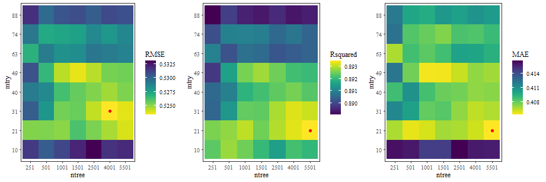

```r
p
```

```r
if (saveplots){
  ggsave(filename="PtsABdAnnoyMnAllVarsHyperTune.svg", width=12, height=4, path=file.path(outFigPath, "svg"))
  unlink("PtsABdAnnoyMnAllVarsHyperTune.svg")

  ggsave(filename="PtsABdAnnoyMnAllVarsHyperTune.pdf", width=12, height=4, path=file.path(outFigPath, "pdf"))
  unlink("PtsABdAnnoyMnAllVarsHyperTune.pdf")
}
```

Selected hyperparameters

```r
ntree <- 1501
mtry <- as.integer(length(iVars)/2.25)
```

#### Run model

Train preliminary model

```r
nperm <- 5

resultsOutAbsDiffs <- crfReg(dataIn=stimDataNum, iVars=iVars, dVar=dVar, seeds=seeds[1:2], ntree=ntree, mtry=mtry, permImpCondThres=permImpCondThres, nperm=nperm, minsplit=minsplit, minbucket=minbucket)

# print model prediction results
resultsOutAbsDiffs$OOB_RMSE
```

```
[1] 0.5256438
```

```r
resultsOutAbsDiffs$OOB_MAE
```

```
[1] 0.4066345
```

```r
resultsOutAbsDiffs$Rsquared
```

```
[1] 0.8918909
```

Train multiple seeds model

```r
resultsOutAbsDiffs <- multi_crfReg(dataIn=stimDataNum, iVars=iVars, dVar=dVar, seeds=seeds, ntree=ntree, mtry=mtry, permImpCondThres=permImpCondThres, nperm=nperm, minsplit=minsplit, minbucket=minbucket)

# print model prediction results
resultsOutAbsDiffs$OOB_RMSE
```

```
[1] 0.5251794
```

```r
resultsOutAbsDiffs$OOB_MAE
```

```
[1] 0.4073787
```

```r
resultsOutAbsDiffs$Rsquared
```

```
[1] 0.8921783
```

```r
# store results
resdAnnoyMnFitAB['All vars', 'RMSE'] <- resultsOutAbsDiffs$OOB_RMSE
resdAnnoyMnFitAB['All vars', 'MAE'] <- resultsOutAbsDiffs$OOB_MAE
resdAnnoyMnFitAB['All vars', 'Rsquared'] <- resultsOutAbsDiffs$Rsquared
resdAnnoyMnPermImpAB$AllVars <- resultsOutAbsDiffs$conditional_permimp
```

#### Plot results

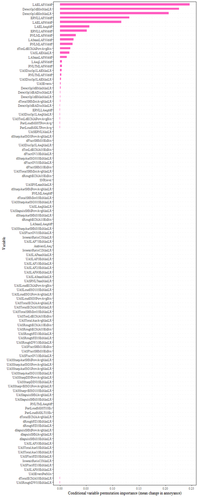

```r
par(mai=c(0,3,0,0))

# plot conditional importance
resultsOutAbsDiffs.conimp <- arrange(resultsOutAbsDiffs$conditional_permimp, desc(row_number()))

pBar <- ggplot(resultsOutAbsDiffs.conimp) + geom_col(aes(x=factor(rownames(resultsOutAbsDiffs.conimp), levels=rownames(resultsOutAbsDiffs.conimp)), y=CondPermImp), fill=mycolours[9], width=0.5) + labs(x="Variable", y="Conditional variable permutation importance (mean change in annoyance)") + theme(text = element_text(family = "serif"), panel.grid=element_line(color = rgb(235, 235, 235, 100, maxColorValue = 255), linewidth = 0.25, linetype = 2)) + coord_flip()
pBar
```

```r
if (saveplots){
  ggsave(filename="PtsABdAnnoyMnAllVarsConPermimp.svg", width=8, height=20, path=file.path(outFigPath, "svg"))
  unlink("PtsABdAnnoyMnAllVarsConPermimp.svg")

  ggsave(filename="PtsABdAnnoyMnAllVarsConPermimp.pdf", width=8, height=20, path=file.path(outFigPath, "pdf"))
  unlink("PtsABdAnnoyMnAllVarsConPermimp.pdf")
}
```

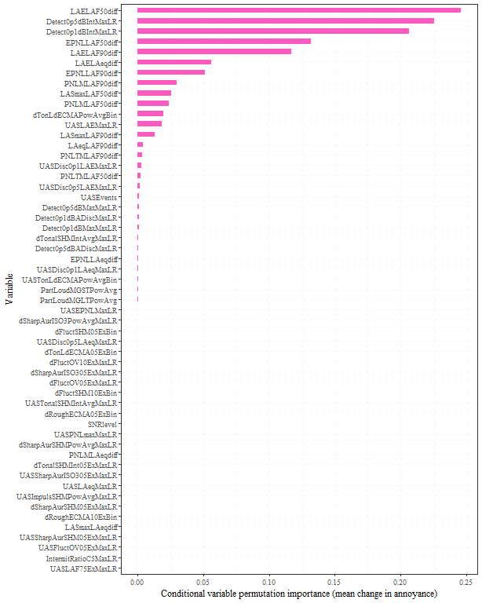

```r
# Plot only positive values

resultsOutAbsDiffs.conimpPtv <- resultsOutAbsDiffs.conimp |>
                                          rownames_to_column('Metric') |>
                                                filter_if(is.numeric, all_vars(. > 0)) |>
                                                      column_to_rownames('Metric')

pBar <- ggplot(resultsOutAbsDiffs.conimpPtv) + geom_col(aes(x=factor(rownames(resultsOutAbsDiffs.conimpPtv), levels=rownames(resultsOutAbsDiffs.conimpPtv)), y=CondPermImp), fill=mycolours[9], width=0.5) + labs(x="Variable", y="Conditional variable permutation importance (mean change in annoyance)") + theme(text = element_text(family = "serif"), panel.grid=element_line(color = rgb(235, 235, 235, 100, maxColorValue = 255), linewidth = 0.25, linetype = 2)) + coord_flip()
pBar
```

```r
if (saveplots){
  ggsave(filename="PtsABdAnnoyMnAllVarsConPermimpPtv.svg", width=8, height=10, path=file.path(outFigPath, "svg"))
  unlink("PtsABdAnnoyMnAllVarsConPermimp.svg")

  ggsave(filename="PtsABdAnnoyMnAllVarsConPermimpPtv.pdf", width=8, height=10, path=file.path(outFigPath, "pdf"))
  unlink("PtsABdAnnoyMnAllVarsConPermimp.pdf")
}
```

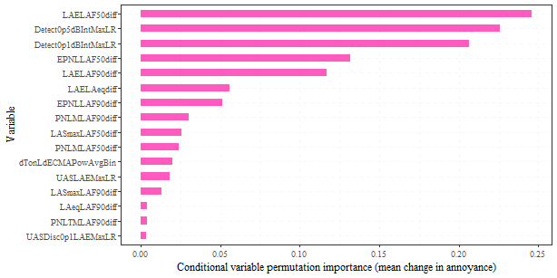

```r
# Plot only values within 1% of the maximum

resultsOutAbsDiffs.conimp1pc <- resultsOutAbsDiffs.conimp |>
                                          rownames_to_column('Metric') |>
                                                filter_if(is.numeric, all_vars(. > max(resultsOutAbsDiffs.conimp)/100)) |>
                                                      column_to_rownames('Metric')

pBar <- ggplot(resultsOutAbsDiffs.conimp1pc) + geom_col(aes(x=factor(rownames(resultsOutAbsDiffs.conimp1pc), levels=rownames(resultsOutAbsDiffs.conimp1pc)), y=CondPermImp), fill=mycolours[9], width=0.5) + labs(x="Variable", y="Conditional variable permutation importance (mean change in annoyance)") + theme(text = element_text(family = "serif"), panel.grid=element_line(color = rgb(235, 235, 235, 100, maxColorValue = 255), linewidth = 0.25, linetype = 2)) + coord_flip()
pBar
```

```r
if (saveplots){
  ggsave(filename="PtsABdAnnoyMnAllVarsConPermimp1pc.svg", width=8, height=4, path=file.path(outFigPath, "svg"))
  unlink("PtsABdAnnoyMnAllVarsConPermimp1pc.svg")

  ggsave(filename="PtsABdAnnoyMnAllVarsConPermimp1pc.pdf", width=8, height=4, path=file.path(outFigPath, "pdf"))
  unlink("PtsABdAnnoyMnAllVarsConPermimp1pc.pdf")
}
```

### Absolute variables

#### Set variables

```r
iVars <- names(stimDataNum)[which(names(stimDataNum) == 'UASEvents'):which(names(stimDataNum) == 'UASImpulsSHM05ExMaxLR')]
iVars <- iVars[! iVars %in% c('SNRlevel', 'IntermitRatioMaxLR')]
dVar <- "dAnnoyMean"

seeds <- c(578312, 544, 84894, 54654, 153157)
```

#### Hyperparameter tuning

```r
p <- mtryTune(dataIn=stimDataNum, iVars=iVars, dVar=dVar, seed=seeds[1:2],
              ntrees=ntrees, minsplit=minsplit, minbucket=minbucket)
```

| RMSE | Rsquared | MAE | mtry | iVars_mtry |
| --- | --- | --- | --- | --- |
| 0.9748321 | 0.6508917 | 0.8404868 | 5 | 10.50 |
| 0.8633048 | 0.7385498 | 0.7320874 | 10 | 5.25 |
| 0.8047005 | 0.7807580 | 0.6674748 | 15 | 3.50 |
| 0.7651087 | 0.8045877 | 0.6285266 | 20 | 2.75 |
| 0.7321442 | 0.8188529 | 0.5956063 | 24 | 2.25 |
| 0.7173931 | 0.8229789 | 0.5684822 | 31 | 1.75 |
| 0.7070334 | 0.8240290 | 0.5613453 | 36 | 1.50 |
| 0.7131250 | 0.8139465 | 0.5472232 | 44 | 1.25 |

| RMSE | Rsquared | MAE | mtry | iVars_mtry |
| --- | --- | --- | --- | --- |
| 0.9676166 | 0.6566060 | 0.8330410 | 5 | 10.50 |
| 0.8679687 | 0.7347074 | 0.7354974 | 10 | 5.25 |
| 0.8159233 | 0.7677402 | 0.6773815 | 15 | 3.50 |
| 0.7632883 | 0.8065713 | 0.6247492 | 20 | 2.75 |
| 0.7461805 | 0.8102145 | 0.6038863 | 24 | 2.25 |
| 0.7115321 | 0.8261763 | 0.5655632 | 31 | 1.75 |
| 0.7028636 | 0.8270341 | 0.5562704 | 36 | 1.50 |
| 0.7087137 | 0.8158341 | 0.5426391 | 44 | 1.25 |

| RMSE | Rsquared | MAE | mtry | iVars_mtry |
| --- | --- | --- | --- | --- |
| 0.9817169 | 0.6427684 | 0.8444668 | 5 | 10.50 |
| 0.8763052 | 0.7292033 | 0.7440977 | 10 | 5.25 |
| 0.8095086 | 0.7730750 | 0.6723949 | 15 | 3.50 |
| 0.7572651 | 0.8081821 | 0.6198083 | 20 | 2.75 |
| 0.7416076 | 0.8132946 | 0.6001744 | 24 | 2.25 |
| 0.7139157 | 0.8244523 | 0.5690301 | 31 | 1.75 |
| 0.7032070 | 0.8262938 | 0.5544346 | 36 | 1.50 |
| 0.7043702 | 0.8175699 | 0.5396857 | 44 | 1.25 |

| RMSE | Rsquared | MAE | mtry | iVars_mtry |
| --- | --- | --- | --- | --- |
| 0.9860757 | 0.6388369 | 0.8482361 | 5 | 10.50 |
| 0.8790683 | 0.7253284 | 0.7455882 | 10 | 5.25 |
| 0.8105441 | 0.7731719 | 0.6735362 | 15 | 3.50 |
| 0.7681250 | 0.8008665 | 0.6297572 | 20 | 2.75 |
| 0.7444793 | 0.8121074 | 0.6040178 | 24 | 2.25 |
| 0.7186278 | 0.8211215 | 0.5717141 | 31 | 1.75 |
| 0.7019690 | 0.8267655 | 0.5531761 | 36 | 1.50 |
| 0.7026299 | 0.8188843 | 0.5385327 | 44 | 1.25 |

| RMSE | Rsquared | MAE | mtry | iVars_mtry |
| --- | --- | --- | --- | --- |
| 0.9872464 | 0.6381319 | 0.8498002 | 5 | 10.50 |
| 0.8785674 | 0.7253259 | 0.7452674 | 10 | 5.25 |
| 0.8065090 | 0.7766994 | 0.6706013 | 15 | 3.50 |
| 0.7648504 | 0.8023679 | 0.6264298 | 20 | 2.75 |
| 0.7397024 | 0.8153839 | 0.6003556 | 24 | 2.25 |
| 0.7129717 | 0.8251780 | 0.5692354 | 31 | 1.75 |
| 0.6984869 | 0.8287997 | 0.5511824 | 36 | 1.50 |
| 0.7006119 | 0.8203929 | 0.5374192 | 44 | 1.25 |

| RMSE | Rsquared | MAE | mtry | iVars_mtry |
| --- | --- | --- | --- | --- |
| 0.9837280 | 0.6413569 | 0.8463140 | 5 | 10.50 |
| 0.8750245 | 0.7284930 | 0.7413291 | 10 | 5.25 |
| 0.8076628 | 0.7762826 | 0.6724931 | 15 | 3.50 |
| 0.7623955 | 0.8040964 | 0.6245198 | 20 | 2.75 |
| 0.7378912 | 0.8161431 | 0.5984234 | 24 | 2.25 |
| 0.7106405 | 0.8271587 | 0.5685790 | 31 | 1.75 |
| 0.6991598 | 0.8286432 | 0.5515100 | 36 | 1.50 |
| 0.6980914 | 0.8221393 | 0.5362071 | 44 | 1.25 |

| RMSE | Rsquared | MAE | mtry | iVars_mtry |
| --- | --- | --- | --- | --- |
| 0.9875130 | 0.6376700 | 0.8493919 | 5 | 10.50 |
| 0.8762716 | 0.7267556 | 0.7424952 | 10 | 5.25 |
| 0.8066026 | 0.7772230 | 0.6721548 | 15 | 3.50 |
| 0.7617919 | 0.8046651 | 0.6240890 | 20 | 2.75 |
| 0.7375706 | 0.8162030 | 0.5978347 | 24 | 2.25 |
| 0.7108113 | 0.8271688 | 0.5696066 | 31 | 1.75 |
| 0.6989885 | 0.8286727 | 0.5514458 | 36 | 1.50 |
| 0.6991994 | 0.8212666 | 0.5369671 | 44 | 1.25 |

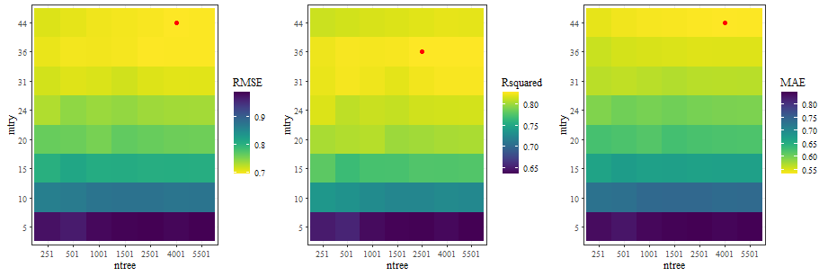

```r
p
```

```r
if (saveplots){
  ggsave(filename="PtsABdAnnoyMnAbsVarsHyperTune.svg", width=12, height=4, path=file.path(outFigPath, "svg"))
  unlink("PtsABdAnnoyMnAbsVarsHyperTune.svg")

  ggsave(filename="PtsABdAnnoyMnAbsVarsHyperTune.pdf", width=12, height=4, path=file.path(outFigPath, "pdf"))
  unlink("PtsABdAnnoyMnAbsVarsHyperTune.pdf")
}
```

Selected hyperparameters

```r
ntree <- 2501
mtry <- as.integer(length(iVars)/1.25)
```

#### Run model

Train preliminary model

```r
nperm <- 15

resultsOutAbs <- crfReg(dataIn=stimDataNum, iVars=iVars, dVar=dVar, seeds=seeds[1:2], ntree=ntree, mtry=mtry, permImpCondThres=permImpCondThres, nperm=nperm, minsplit=minsplit, minbucket=minbucket)

# print model prediction results
resultsOutAbs$OOB_RMSE
```

```
[1] 0.7088118
```

```r
resultsOutAbs$OOB_MAE
```

```
[1] 0.5411488
```

```r
resultsOutAbs$Rsquared
```

```
[1] 0.8135322
```

Train multiple seeds model

```r
resultsOutAbs <- multi_crfReg(dataIn=stimDataNum, iVars=iVars, dVar=dVar, seeds=seeds, ntree=ntree, mtry=mtry, permImpCondThres=permImpCondThres, nperm=nperm, minsplit=minsplit, minbucket=minbucket)

# print model prediction results
resultsOutAbs$OOB_RMSE
```

```
[1] 0.7076585
```

```r
resultsOutAbs$OOB_MAE
```

```
[1] 0.5409705
```

```r
resultsOutAbs$Rsquared
```

```
[1] 0.813819
```

```r
# store results
resdAnnoyMnFitAB['Abs vars', 'RMSE'] <- resultsOutAbs$OOB_RMSE
resdAnnoyMnFitAB['Abs vars', 'MAE'] <- resultsOutAbs$OOB_MAE
resdAnnoyMnFitAB['Abs vars', 'Rsquared'] <- resultsOutAbs$Rsquared
resdAnnoyMnPermImpAB$AbsVars <- resultsOutAbs$conditional_permimp
```

#### Plot results

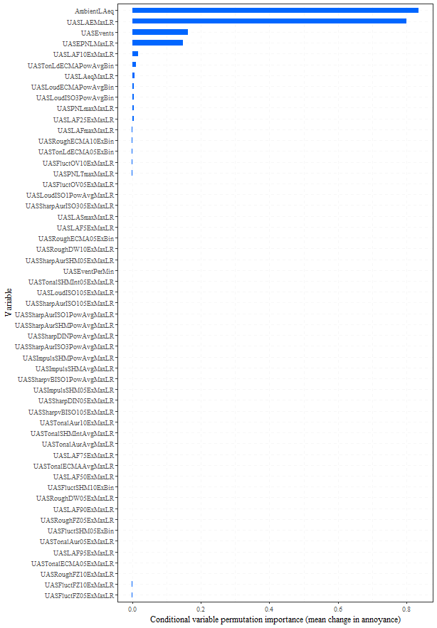

```r
par(mai=c(0,3,0,0))

# plot conditional importance
resultsOutAbs.conimp <- arrange(resultsOutAbs$conditional_permimp, desc(row_number()))

pBar <- ggplot(resultsOutAbs.conimp) + geom_col(aes(x=factor(rownames(resultsOutAbs.conimp), levels=rownames(resultsOutAbs.conimp)), y=CondPermImp), fill=mycolours[1], width=0.5) + labs(x="Variable", y="Conditional variable permutation importance (mean change in annoyance)") + theme(text = element_text(family = "serif"), panel.grid=element_line(color = rgb(235, 235, 235, 100, maxColorValue = 255), linewidth = 0.25, linetype = 2)) +
  coord_flip()
pBar
```

```r
if (saveplots){
  ggsave(filename="PtsABdAnnoyMnAbsVarsConPermimp.svg", width=8, height=11.5, path=file.path(outFigPath, "svg"))
  unlink("PtsABdAnnoyMnAbsVarsConPermimp.svg")

  ggsave(filename="PtsABdAnnoyMnAbsVarsConPermimp.pdf", width=8, height=11.5, path=file.path(outFigPath, "pdf"))
  unlink("PtsABdAnnoyMnAbsVarsConPermimp.pdf")
}
```

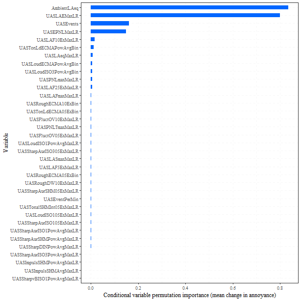

```r
# Plot only positive values

resultsOutAbs.conimpPtv <- resultsOutAbs.conimp |>
                                          rownames_to_column('Metric') |>
                                                filter_if(is.numeric, all_vars(. > 0)) |>
                                                      column_to_rownames('Metric')

pBar <- ggplot(resultsOutAbs.conimpPtv) + geom_col(aes(x=factor(rownames(resultsOutAbs.conimpPtv), levels=rownames(resultsOutAbs.conimpPtv)), y=CondPermImp), fill=mycolours[1], width=0.5) + labs(x="Variable", y="Conditional variable permutation importance (mean change in annoyance)") + theme(text = element_text(family = "serif"), panel.grid=element_line(color = rgb(235, 235, 235, 100, maxColorValue = 255), linewidth = 0.25, linetype = 2)) + coord_flip()
pBar
```

```r
if (saveplots){
  ggsave(filename="PtsABdAnnoyMnAbsVarsConPermimpPtv.svg", width=8, height=8, path=file.path(outFigPath, "svg"))
  unlink("PtsABdAnnoyMnAbsVarsConPermimpPtv.svg")

  ggsave(filename="PtsABdAnnoyMnAbsVarsConPermimpPtv.pdf", width=8, height=8, path=file.path(outFigPath, "pdf"))
  unlink("PtsABdAnnoyMnAbsVarsConPermimpPtv.pdf")
}
```

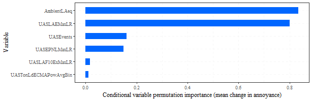

```r
# Plot only values within 1% of the maximum

resultsOutAbs.conimp1pc <- resultsOutAbs.conimp |>
                                          rownames_to_column('Metric') |>
                                                filter_if(is.numeric, all_vars(. > max(resultsOutAbs.conimp)/100)) |>
                                                      column_to_rownames('Metric')

pBar <- ggplot(resultsOutAbs.conimp1pc) + geom_col(aes(x=factor(rownames(resultsOutAbs.conimp1pc), levels=rownames(resultsOutAbs.conimp1pc)), y=CondPermImp), fill=mycolours[1], width=0.5) + labs(x="Variable", y="Conditional variable permutation importance (mean change in annoyance)") + theme(text = element_text(family = "serif"), panel.grid=element_line(color = rgb(235, 235, 235, 100, maxColorValue = 255), linewidth = 0.25, linetype = 2)) + coord_flip()
pBar
```

```r
if (saveplots){
  ggsave(filename="PtsABdAnnoyMnAbsVarsConPermimp1pc.svg", width=8, height=2.6, path=file.path(outFigPath, "svg"))
  unlink("PtsABdAnnoyMnAbsVarsConPermimp1pc.svg")

  ggsave(filename="PtsABdAnnoyMnAbsVarsConPermimp1pc.pdf", width=8, height=2.6, path=file.path(outFigPath, "pdf"))
  unlink("PtsABdAnnoyMnAbsVarsConPermimp1pc.pdf")
}
```

Selected metric

```r
absVar <- "UASLAEMaxLR"
```

### SQM analysis

#### Replace ambient only stimuli

The ambient-only stimuli are NOT replaced here, as the analysis cannot handle missing values for dB metrics.

#### Individual SQMs

##### Sharpness

###### Set variables

```r
iVars <- c(absVar, eventVar, ambVar, "UASSharpAurISO3PowAvgMaxLR", "UASSharpAurISO305ExMaxLR", "UASSharpAurSHMPowAvgMaxLR", "UASSharpAurSHM05ExMaxLR", "UASSharpAurISO1PowAvgMaxLR", "UASSharpAurISO105ExMaxLR", "UASSharpvBISO1PowAvgMaxLR", "UASSharpvBISO105ExMaxLR", "UASSharpDINPowAvgMaxLR", "UASSharpDIN05ExMaxLR")
dVar <- "dAnnoyMean"

seeds <- c(7041, 905, 4984651, 6513213, 120651)
```

###### Hyperparameter tuning

```r
p <- mtryTune(dataIn=stimDataNum, iVars=iVars, dVar=dVar, seed=seeds[1:2],
             ntrees=ntrees, minsplit=minsplit, minbucket=minbucket)
```

| RMSE | Rsquared | MAE | mtry | iVars_mtry |
| --- | --- | --- | --- | --- |
| 0.9214172 | 0.7361572 | 0.7911028 | 2 | 5.25 |
| 0.8462134 | 0.7973225 | 0.7158788 | 3 | 3.50 |
| 0.7536142 | 0.8423046 | 0.6331174 | 4 | 2.75 |
| 0.7143040 | 0.8615251 | 0.5965818 | 5 | 2.25 |
| 0.6341884 | 0.8831179 | 0.5213618 | 7 | 1.75 |
| 0.6546231 | 0.8708422 | 0.5420809 | 8 | 1.50 |
| 0.6356029 | 0.8653657 | 0.5084205 | 10 | 1.25 |

| RMSE | Rsquared | MAE | mtry | iVars_mtry |
| --- | --- | --- | --- | --- |
| 0.9355235 | 0.7272211 | 0.8033724 | 2 | 5.25 |
| 0.8428490 | 0.7971724 | 0.7157170 | 3 | 3.50 |
| 0.7446262 | 0.8477930 | 0.6244856 | 4 | 2.75 |
| 0.6988680 | 0.8687913 | 0.5822947 | 5 | 2.25 |
| 0.6478257 | 0.8781045 | 0.5359412 | 7 | 1.75 |
| 0.6485335 | 0.8730318 | 0.5358934 | 8 | 1.50 |
| 0.6370767 | 0.8638594 | 0.5097680 | 10 | 1.25 |

| RMSE | Rsquared | MAE | mtry | iVars_mtry |
| --- | --- | --- | --- | --- |
| 0.9391081 | 0.7277773 | 0.8089063 | 2 | 5.25 |
| 0.8327404 | 0.8041220 | 0.7058208 | 3 | 3.50 |
| 0.7451635 | 0.8494465 | 0.6242706 | 4 | 2.75 |
| 0.6994612 | 0.8658493 | 0.5824599 | 5 | 2.25 |
| 0.6502155 | 0.8767439 | 0.5376551 | 7 | 1.75 |
| 0.6473492 | 0.8729949 | 0.5333398 | 8 | 1.50 |
| 0.6382168 | 0.8628134 | 0.5105386 | 10 | 1.25 |

| RMSE | Rsquared | MAE | mtry | iVars_mtry |
| --- | --- | --- | --- | --- |
| 0.9374279 | 0.7287904 | 0.8066031 | 2 | 5.25 |
| 0.8263963 | 0.8072118 | 0.7001407 | 3 | 3.50 |
| 0.7448206 | 0.8495553 | 0.6235153 | 4 | 2.75 |
| 0.7019349 | 0.8643287 | 0.5855645 | 5 | 2.25 |
| 0.6528406 | 0.8763869 | 0.5394758 | 7 | 1.75 |
| 0.6447145 | 0.8736779 | 0.5303399 | 8 | 1.50 |
| 0.6396602 | 0.8629486 | 0.5126904 | 10 | 1.25 |

| RMSE | Rsquared | MAE | mtry | iVars_mtry |
| --- | --- | --- | --- | --- |
| 0.9336129 | 0.7337447 | 0.8018647 | 2 | 5.25 |
| 0.8258296 | 0.8067578 | 0.6994306 | 3 | 3.50 |
| 0.7464654 | 0.8505928 | 0.6244286 | 4 | 2.75 |
| 0.7052957 | 0.8625928 | 0.5887403 | 5 | 2.25 |
| 0.6528169 | 0.8757590 | 0.5387898 | 7 | 1.75 |
| 0.6446332 | 0.8745395 | 0.5290889 | 8 | 1.50 |
| 0.6381378 | 0.8638607 | 0.5110062 | 10 | 1.25 |

| RMSE | Rsquared | MAE | mtry | iVars_mtry |
| --- | --- | --- | --- | --- |
| 0.9319490 | 0.7339128 | 0.8005471 | 2 | 5.25 |
| 0.8268013 | 0.8051008 | 0.7007119 | 3 | 3.50 |
| 0.7471067 | 0.8498725 | 0.6261385 | 4 | 2.75 |
| 0.7035107 | 0.8643221 | 0.5875476 | 5 | 2.25 |
| 0.6566107 | 0.8740374 | 0.5416347 | 7 | 1.75 |
| 0.6463625 | 0.8733618 | 0.5299147 | 8 | 1.50 |
| 0.6403835 | 0.8632109 | 0.5133152 | 10 | 1.25 |

| RMSE | Rsquared | MAE | mtry | iVars_mtry |
| --- | --- | --- | --- | --- |
| 0.9321074 | 0.7340879 | 0.8011058 | 2 | 5.25 |
| 0.8248176 | 0.8072803 | 0.6986252 | 3 | 3.50 |
| 0.7478689 | 0.8495568 | 0.6268416 | 4 | 2.75 |
| 0.7046846 | 0.8650194 | 0.5890396 | 5 | 2.25 |
| 0.6541195 | 0.8755409 | 0.5403290 | 7 | 1.75 |
| 0.6450597 | 0.8735607 | 0.5284694 | 8 | 1.50 |
| 0.6419118 | 0.8626113 | 0.5143042 | 10 | 1.25 |

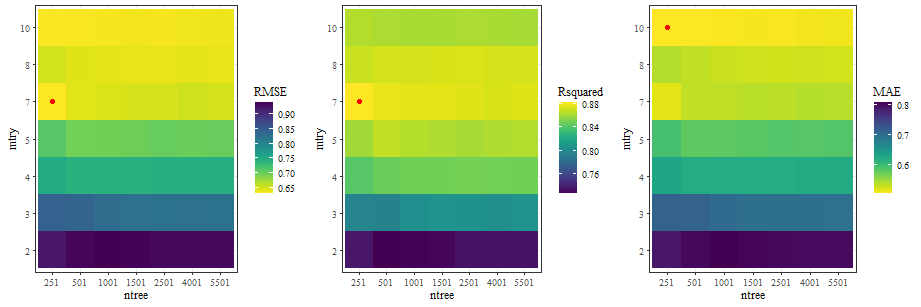

```r
p
```

Selected hyperparameters

```r
ntree <- 251
mtry <- as.integer(length(iVars)/1.25)
```

###### Run model

Train preliminary model

```r
nperm <- 5

resultsOutSharp <- crfReg(dataIn=stimDataNum, iVars=iVars, dVar=dVar, seeds=seeds[1:2], ntree=ntree, mtry=mtry, permImpCondThres=permImpCondThres, nperm=nperm, minsplit=minsplit, minbucket=minbucket)

# print model prediction results
resultsOutSharp$OOB_RMSE
```

```
[1] 0.6858492
```

```r
resultsOutSharp$OOB_MAE
```

```
[1] 0.5280757
```

```r
resultsOutSharp$Rsquared
```

```
[1] 0.8259828
```

Train multiple seeds model

```r
resultsOutSharp <- multi_crfReg(dataIn=stimDataNum, iVars=iVars, dVar=dVar, seeds=seeds, ntree=ntree, mtry=mtry, permImpCondThres=permImpCondThres, nperm=nperm, minsplit=minsplit, minbucket=minbucket)

# print model prediction results
resultsOutSharp$OOB_RMSE
```

```
[1] 0.6713488
```

```r
resultsOutSharp$OOB_MAE
```

```
[1] 0.5186261
```

```r
resultsOutSharp$Rsquared
```

```
[1] 0.835576
```

```r
# store results
resdAnnoyMnFitAB['Abs sharp', 'RMSE'] <- resultsOutSharp$OOB_RMSE
resdAnnoyMnFitAB['Abs sharp', 'MAE'] <- resultsOutSharp$OOB_MAE
resdAnnoyMnFitAB['Abs sharp', 'Rsquared'] <- resultsOutSharp$Rsquared
resdAnnoyMnPermImpAB$AbsSharp <- resultsOutSharp$conditional_permimp
```

###### Plot results

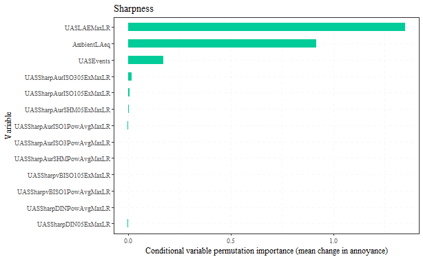

```r
par(mai=c(0,3,0,0))

# plot conditional importance
resultsOutSharp.conimp <- arrange(resultsOutSharp$conditional_permimp, desc(row_number()))

pBar <- ggplot(resultsOutSharp.conimp) + geom_col(aes(x=factor(rownames(resultsOutSharp.conimp), levels=rownames(resultsOutSharp.conimp)), y=CondPermImp), fill=mycolours[2], width=0.5) + labs(x="Variable", y="Conditional variable permutation importance (mean change in annoyance)") + ggtitle("Sharpness") + theme(text = element_text(family = "serif"), panel.grid=element_line(color = rgb(235, 235, 235, 100, maxColorValue = 255), linewidth = 0.25, linetype = 2)) + coord_flip()
pBar
```

```r
if (saveplots){
  ggsave(filename="PtsABdAnnoyMnSharpConPermimp.svg", width=8, height=4.9, path=file.path(outFigPath, "svg"))
  unlink("PtsABdAnnoyMnSharpConPermimp.svg")

  ggsave(filename="PtsABdAnnoyMnSharpConPermimp.pdf", width=8, height=4.9, path=file.path(outFigPath, "pdf"))
  unlink("PtsABdAnnoyMnSharpConPermimp.pdf")
}
```

Selected metric

```r
sharpVar <- "UASSharpAurISO305ExMaxLR"
```

##### Tonal loudness and tonality

###### Set variables

```r
iVars <- c(absVar, eventVar, ambVar, "UASTonalECMAAvgMaxLR", "UASTonalSHMInt05ExMaxLR", "UASTonalSHMIntAvgMaxLR", "UASTonalECMA05ExMaxLR", "UASTonLdECMAPowAvgBin", "UASTonLdECMA05ExBin", "UASTonalAurAvgMaxLR", "UASTonalAur05ExMaxLR", "UASTonalAur10ExMaxLR")
dVar <- "dAnnoyMean"

seeds <- c(540, 104798, 456464, 87331, 94564)
```

###### Hyperparameter tuning

```r
p <- mtryTune(dataIn=stimDataNum, iVars=iVars, dVar=dVar, seed=seeds[1:2],
             ntrees=ntrees, minsplit=minsplit, minbucket=minbucket)
```

| RMSE | Rsquared | MAE | mtry | iVars_mtry |
| --- | --- | --- | --- | --- |
| 0.8947770 | 0.7559987 | 0.7564269 | 2 | 5.25 |
| 0.7688330 | 0.8289949 | 0.6356989 | 3 | 3.50 |
| 0.7589813 | 0.8221007 | 0.6315492 | 4 | 2.75 |
| 0.6970093 | 0.8549721 | 0.5754647 | 5 | 2.25 |
| 0.6816873 | 0.8560249 | 0.5649619 | 6 | 1.75 |
| 0.6608587 | 0.8518113 | 0.5354598 | 8 | 1.50 |
| 0.6530115 | 0.8544185 | 0.5261027 | 9 | 1.25 |

| RMSE | Rsquared | MAE | mtry | iVars_mtry |
| --- | --- | --- | --- | --- |
| 0.8882836 | 0.7606325 | 0.7497713 | 2 | 5.25 |
| 0.7863488 | 0.8201284 | 0.6522943 | 3 | 3.50 |
| 0.7372591 | 0.8383889 | 0.6114632 | 4 | 2.75 |
| 0.6923813 | 0.8588040 | 0.5735691 | 5 | 2.25 |
| 0.6753100 | 0.8609140 | 0.5601310 | 6 | 1.75 |
| 0.6533814 | 0.8568356 | 0.5324359 | 8 | 1.50 |
| 0.6383917 | 0.8637911 | 0.5164646 | 9 | 1.25 |

| RMSE | Rsquared | MAE | mtry | iVars_mtry |
| --- | --- | --- | --- | --- |
| 0.8802064 | 0.7672886 | 0.7428920 | 2 | 5.25 |
| 0.7909283 | 0.8154335 | 0.6559928 | 3 | 3.50 |
| 0.7380485 | 0.8375660 | 0.6140466 | 4 | 2.75 |
| 0.6925433 | 0.8558805 | 0.5720873 | 5 | 2.25 |
| 0.6751643 | 0.8604288 | 0.5589877 | 6 | 1.75 |
| 0.6545229 | 0.8581412 | 0.5326613 | 8 | 1.50 |
| 0.6464344 | 0.8607846 | 0.5240322 | 9 | 1.25 |

| RMSE | Rsquared | MAE | mtry | iVars_mtry |
| --- | --- | --- | --- | --- |
| 0.8839754 | 0.7636536 | 0.7454058 | 2 | 5.25 |
| 0.7938012 | 0.8150418 | 0.6577899 | 3 | 3.50 |
| 0.7351490 | 0.8398410 | 0.6102536 | 4 | 2.75 |
| 0.6897200 | 0.8581616 | 0.5698549 | 5 | 2.25 |
| 0.6751752 | 0.8606434 | 0.5585987 | 6 | 1.75 |
| 0.6519383 | 0.8605460 | 0.5320677 | 8 | 1.50 |
| 0.6461327 | 0.8620508 | 0.5238866 | 9 | 1.25 |

| RMSE | Rsquared | MAE | mtry | iVars_mtry |
| --- | --- | --- | --- | --- |
| 0.8790724 | 0.7697385 | 0.7421473 | 2 | 5.25 |
| 0.7946938 | 0.8139130 | 0.6594104 | 3 | 3.50 |
| 0.7319728 | 0.8423410 | 0.6073850 | 4 | 2.75 |
| 0.6977861 | 0.8528470 | 0.5758512 | 5 | 2.25 |
| 0.6748004 | 0.8607271 | 0.5571935 | 6 | 1.75 |
| 0.6533495 | 0.8602546 | 0.5327556 | 8 | 1.50 |
| 0.6480318 | 0.8603580 | 0.5240709 | 9 | 1.25 |

| RMSE | Rsquared | MAE | mtry | iVars_mtry |
| --- | --- | --- | --- | --- |
| 0.8779436 | 0.7708697 | 0.7415975 | 2 | 5.25 |
| 0.7919810 | 0.8154056 | 0.6566441 | 3 | 3.50 |
| 0.7356271 | 0.8397065 | 0.6101039 | 4 | 2.75 |
| 0.7012533 | 0.8507860 | 0.5788367 | 5 | 2.25 |
| 0.6719051 | 0.8623778 | 0.5550117 | 6 | 1.75 |
| 0.6527192 | 0.8611851 | 0.5317059 | 8 | 1.50 |
| 0.6485023 | 0.8601985 | 0.5246424 | 9 | 1.25 |

| RMSE | Rsquared | MAE | mtry | iVars_mtry |
| --- | --- | --- | --- | --- |
| 0.8738531 | 0.7746703 | 0.7375091 | 2 | 5.25 |
| 0.7895036 | 0.8167828 | 0.6546815 | 3 | 3.50 |
| 0.7349299 | 0.8411652 | 0.6092522 | 4 | 2.75 |
| 0.7024363 | 0.8506180 | 0.5803563 | 5 | 2.25 |
| 0.6725627 | 0.8617316 | 0.5556179 | 6 | 1.75 |
| 0.6511405 | 0.8621042 | 0.5307142 | 8 | 1.50 |
| 0.6484356 | 0.8601062 | 0.5247974 | 9 | 1.25 |

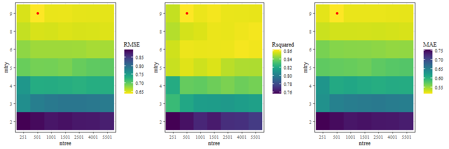

```r
p
```

Selected hyperparameters

```r
ntree <- 501
mtry <- as.integer(length(iVars)/1.25)
```

###### Run model

Train preliminary model

```r
# Tonality with tonal loudness

nperm <- 5

resultsOutTonal1 <- crfReg(dataIn=stimDataNum, iVars=iVars, dVar=dVar, seeds=seeds[1:2], ntree=ntree, mtry=mtry, permImpCondThres=permImpCondThres, nperm=nperm, minsplit=minsplit, minbucket=minbucket)

# print model prediction results
resultsOutTonal1$OOB_RMSE
```

```
[1] 0.6811661
```

```r
resultsOutTonal1$OOB_MAE
```

```
[1] 0.5331511
```

```r
resultsOutTonal1$Rsquared
```

```
[1] 0.8324705
```

Train multiple seeds model

```r
# Tonality with tonal loudness

resultsOutTonal1 <- multi_crfReg(dataIn=stimDataNum, iVars=iVars, dVar=dVar, seeds=seeds, ntree=ntree, mtry=mtry, permImpCondThres=permImpCondThres, nperm=nperm, minsplit=minsplit, minbucket=minbucket)

# print model prediction results
resultsOutTonal1$OOB_RMSE
```

```
[1] 0.6704168
```

```r
resultsOutTonal1$OOB_MAE
```

```
[1] 0.5238017
```

```r
resultsOutTonal1$Rsquared
```

```
[1] 0.8379969
```

```r
# store results
resdAnnoyMnFitAB['Abs tonal inc loud', 'RMSE'] <- resultsOutTonal1$OOB_RMSE
resdAnnoyMnFitAB['Abs tonal inc loud', 'MAE'] <- resultsOutTonal1$OOB_MAE
resdAnnoyMnFitAB['Abs tonal inc loud', 'Rsquared'] <- resultsOutTonal1$Rsquared
resdAnnoyMnPermImpAB$AbsTonal1 <- resultsOutTonal1$conditional_permimp
```

###### Plot results

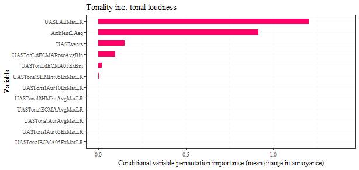

```r
par(mai=c(0,3,0,0))

# plot conditional importance
resultsOutTonal1.conimp <- arrange(resultsOutTonal1$conditional_permimp, desc(row_number()))

pBar <- ggplot(resultsOutTonal1.conimp) + geom_col(aes(x=factor(rownames(resultsOutTonal1.conimp), levels=rownames(resultsOutTonal1.conimp)), y=CondPermImp), fill=mycolours[3], width=0.5) + labs(x="Variable", y="Conditional variable permutation importance (mean change in annoyance)") + ggtitle("Tonality inc. tonal loudness") + theme(text = element_text(family = "serif"), panel.grid=element_line(color = rgb(235, 235, 235, 100, maxColorValue = 255), linewidth = 0.25, linetype = 2)) + coord_flip(ylim=c(0, 1.4))
pBar
```

```r
if (saveplots){
  ggsave(filename="PtsABdAnnoyMnTonalLdConPermimp.svg", width=8, height=3.8, path=file.path(outFigPath, "svg"))
  unlink("PtsABdAnnoyMnTonalLdConPermimp.svg")

  ggsave(filename="PtsABdAnnoyMnTonalLdConPermimp.pdf", width=8, height=3.8, path=file.path(outFigPath, "pdf"))
  unlink("PtsABdAnnoyMnTonalLdConPermimp.pdf")
}
```

Selected metric

```r
tonLdVar <- "UASTonLdECMAPowAvgBin"
```

##### Tonality without tonal loudness

###### Set variables

```r
iVars <- c(absVar, eventVar, ambVar, "UASTonalECMAAvgMaxLR", "UASTonalSHMInt05ExMaxLR", "UASTonalSHMIntAvgMaxLR", "UASTonalECMA05ExMaxLR", "UASTonalAurAvgMaxLR", "UASTonalAur05ExMaxLR", "UASTonalAur10ExMaxLR")
dVar <- "dAnnoyMean"

seeds <- c(156089, 5860, 10528, 89541, 4685146)
```

###### Hyperparameter tuning

```r
p <- mtryTune(dataIn=stimDataNum, iVars=iVars, dVar=dVar, seed=seeds[1:2],
             ntrees=ntrees, minsplit=minsplit, minbucket=minbucket)
```

| RMSE | Rsquared | MAE | mtry | iVars_mtry |
| --- | --- | --- | --- | --- |
| 0.8529399 | 0.8187393 | 0.7084058 | 2 | 3.50 |
| 0.7817244 | 0.8402178 | 0.6433955 | 3 | 2.75 |
| 0.7095674 | 0.8638232 | 0.5794498 | 4 | 2.25 |
| 0.6598451 | 0.8784006 | 0.5371381 | 5 | 1.75 |
| 0.6691422 | 0.8693299 | 0.5394025 | 6 | 1.50 |
| 0.6502143 | 0.8595077 | 0.5236597 | 8 | 1.25 |

| RMSE | Rsquared | MAE | mtry | iVars_mtry |
| --- | --- | --- | --- | --- |
| 0.8500690 | 0.8168848 | 0.7075554 | 2 | 3.50 |
| 0.7722988 | 0.8477631 | 0.6318489 | 3 | 2.75 |
| 0.7123579 | 0.8651486 | 0.5826028 | 4 | 2.25 |
| 0.6712238 | 0.8770458 | 0.5458735 | 5 | 1.75 |
| 0.6608094 | 0.8728116 | 0.5383114 | 6 | 1.50 |
| 0.6464547 | 0.8611659 | 0.5175694 | 8 | 1.25 |

| RMSE | Rsquared | MAE | mtry | iVars_mtry |
| --- | --- | --- | --- | --- |
| 0.8563536 | 0.8132183 | 0.7109456 | 2 | 3.50 |
| 0.7636513 | 0.8503953 | 0.6258250 | 3 | 2.75 |
| 0.7082835 | 0.8687917 | 0.5772201 | 4 | 2.25 |
| 0.6719558 | 0.8752202 | 0.5484144 | 5 | 1.75 |
| 0.6525765 | 0.8770381 | 0.5301985 | 6 | 1.50 |
| 0.6409685 | 0.8640337 | 0.5152221 | 8 | 1.25 |

| RMSE | Rsquared | MAE | mtry | iVars_mtry |
| --- | --- | --- | --- | --- |
| 0.8563296 | 0.8154968 | 0.7106445 | 2 | 3.50 |
| 0.7631648 | 0.8514120 | 0.6278948 | 3 | 2.75 |
| 0.7074546 | 0.8698168 | 0.5759158 | 4 | 2.25 |
| 0.6674566 | 0.8760562 | 0.5446080 | 5 | 1.75 |
| 0.6529088 | 0.8756766 | 0.5303242 | 6 | 1.50 |
| 0.6426188 | 0.8634333 | 0.5157426 | 8 | 1.25 |

| RMSE | Rsquared | MAE | mtry | iVars_mtry |
| --- | --- | --- | --- | --- |
| 0.8535141 | 0.8167545 | 0.7085626 | 2 | 3.50 |
| 0.7681218 | 0.8477863 | 0.6312990 | 3 | 2.75 |
| 0.7121168 | 0.8677361 | 0.5812120 | 4 | 2.25 |
| 0.6716871 | 0.8752256 | 0.5473730 | 5 | 1.75 |
| 0.6484151 | 0.8772288 | 0.5280957 | 6 | 1.50 |
| 0.6435593 | 0.8629178 | 0.5153768 | 8 | 1.25 |

| RMSE | Rsquared | MAE | mtry | iVars_mtry |
| --- | --- | --- | --- | --- |
| 0.8575467 | 0.8162402 | 0.7130606 | 2 | 3.50 |
| 0.7653878 | 0.8498144 | 0.6290693 | 3 | 2.75 |
| 0.7087639 | 0.8696904 | 0.5793950 | 4 | 2.25 |
| 0.6700058 | 0.8765366 | 0.5459621 | 5 | 1.75 |
| 0.6501328 | 0.8760223 | 0.5291400 | 6 | 1.50 |
| 0.6425392 | 0.8639726 | 0.5136155 | 8 | 1.25 |

| RMSE | Rsquared | MAE | mtry | iVars_mtry |
| --- | --- | --- | --- | --- |
| 0.8568467 | 0.8162888 | 0.7128353 | 2 | 3.50 |
| 0.7626431 | 0.8511858 | 0.6274425 | 3 | 2.75 |
| 0.7104207 | 0.8683978 | 0.5808859 | 4 | 2.25 |
| 0.6697613 | 0.8760044 | 0.5460669 | 5 | 1.75 |
| 0.6516735 | 0.8758101 | 0.5301745 | 6 | 1.50 |
| 0.6446907 | 0.8631735 | 0.5148337 | 8 | 1.25 |

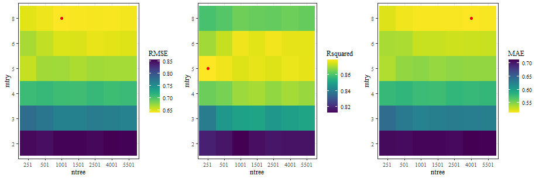

```r
p
```

Selected hyperparameters

```r
ntree <- 1001
mtry <- as.integer(length(iVars)/1.25)
```

###### Run model

Train preliminary model

```r
# Tonality

nperm <- 5

resultsOutTonal2 <- crfReg(dataIn=stimDataNum, iVars=iVars, dVar=dVar, seeds=seeds[1:2], ntree=ntree, mtry=mtry, permImpCondThres=permImpCondThres, nperm=nperm, minsplit=minsplit, minbucket=minbucket)

# print model prediction results
resultsOutTonal2$OOB_RMSE
```

```
[1] 0.6767596
```

```r
resultsOutTonal2$OOB_MAE
```

```
[1] 0.5243451
```

```r
resultsOutTonal2$Rsquared
```

```
[1] 0.8313253
```

Train multiple seeds model

```r
# Tonality

resultsOutTonal2 <- multi_crfReg(dataIn=stimDataNum, iVars=iVars, dVar=dVar, seeds=seeds, ntree=ntree, mtry=mtry, permImpCondThres=permImpCondThres, nperm=nperm, minsplit=minsplit, minbucket=minbucket)

# print model prediction results
resultsOutTonal2$OOB_RMSE
```

```
[1] 0.6797135
```

```r
resultsOutTonal2$OOB_MAE
```

```
[1] 0.527007
```

```r
resultsOutTonal2$Rsquared
```

```
[1] 0.8303318
```

```r
# store results
resdAnnoyMnFitAB['Abs tonal no loud', 'RMSE'] <- resultsOutTonal2$OOB_RMSE
resdAnnoyMnFitAB['Abs tonal no loud', 'MAE'] <- resultsOutTonal2$OOB_MAE
resdAnnoyMnFitAB['Abs tonal no loud', 'Rsquared'] <- resultsOutTonal2$Rsquared
resdAnnoyMnPermImpAB$AbsTonal2 <- resultsOutTonal2$conditional_permimp
```

###### Plot results

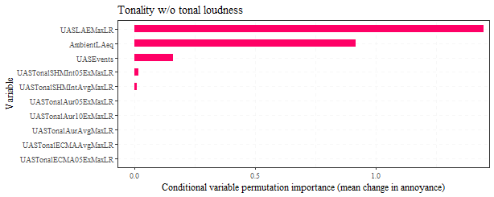

```r
par(mai=c(0,3,0,0))

# plot conditional importance
resultsOutTonal2.conimp <- arrange(resultsOutTonal2$conditional_permimp, desc(row_number()))

pBar <- ggplot(resultsOutTonal2.conimp) + geom_col(aes(x=factor(rownames(resultsOutTonal2.conimp), levels=rownames(resultsOutTonal2.conimp)), y=CondPermImp), fill=mycolours[3], width=0.5) + labs(x="Variable", y="Conditional variable permutation importance (mean change in annoyance)") + ggtitle("Tonality w/o tonal loudness") + theme(text = element_text(family = "serif"), panel.grid=element_line(color = rgb(235, 235, 235, 100, maxColorValue = 255), linewidth = 0.25, linetype = 2)) + coord_flip(ylim=c(0, 1.4))
pBar
```

```r
if (saveplots){
  ggsave(filename="PtsABdAnnoyMnTonalConPermimp.svg", width=8, height=3.2, path=file.path(outFigPath, "svg"))
  unlink("PtsABdAnnoyMnTonalConPermimp.svg")

  ggsave(filename="PtsABdAnnoyMnTonalConPermimp.pdf", width=8, height=3.2, path=file.path(outFigPath, "pdf"))
  unlink("PtsABdAnnoyMnTonalConPermimp.pdf")
}
```

Selected metric

```r
tonalVar <- "UASTonalSHMInt05ExMaxLR"
```

##### Fluctuation strength

###### Set variables

```r
# Fluctuation strength
iVars <- c(absVar, eventVar, ambVar, "UASFluctSHM10ExBin", "UASFluctSHM05ExBin", "UASFluctFZ10ExMaxLR", "UASFluctFZ05ExMaxLR", "UASFluctOV10ExMaxLR", "UASFluctOV05ExMaxLR")
dVar <- "dAnnoyMean"

seeds <- c(25107, 546098, 195, 5937, 102658)
```

###### Hyperparameter tuning

```r
p <- mtryTune(dataIn=stimDataNum, iVars=iVars, dVar=dVar, seed=seeds[1:2],
             ntrees=ntrees, minsplit=minsplit, minbucket=minbucket)
```

| RMSE | Rsquared | MAE | mtry | iVars_mtry |
| --- | --- | --- | --- | --- |
| 0.8799804 | 0.8224446 | 0.7389804 | 2 | 3.50 |
| 0.7420663 | 0.8639959 | 0.6115402 | 3 | 2.75 |
| 0.6971471 | 0.8814167 | 0.5687718 | 4 | 2.25 |
| 0.6622394 | 0.8817147 | 0.5408126 | 5 | 1.75 |
| 0.6422939 | 0.8771540 | 0.5168192 | 6 | 1.50 |
| 0.6378156 | 0.8706450 | 0.4998178 | 7 | 1.25 |

| RMSE | Rsquared | MAE | mtry | iVars_mtry |
| --- | --- | --- | --- | --- |
| 0.8840815 | 0.8222383 | 0.7431954 | 2 | 3.50 |
| 0.7406255 | 0.8683683 | 0.6118029 | 3 | 2.75 |
| 0.6906436 | 0.8831792 | 0.5618847 | 4 | 2.25 |
| 0.6603761 | 0.8866679 | 0.5369156 | 5 | 1.75 |
| 0.6516086 | 0.8751402 | 0.5252772 | 6 | 1.50 |
| 0.6356544 | 0.8723702 | 0.5014332 | 7 | 1.25 |

| RMSE | Rsquared | MAE | mtry | iVars_mtry |
| --- | --- | --- | --- | --- |
| 0.8743007 | 0.8329762 | 0.7342389 | 2 | 3.50 |
| 0.7504322 | 0.8683231 | 0.6203284 | 3 | 2.75 |
| 0.6920852 | 0.8851984 | 0.5660797 | 4 | 2.25 |
| 0.6659688 | 0.8830850 | 0.5398498 | 5 | 1.75 |
| 0.6489097 | 0.8766372 | 0.5220417 | 6 | 1.50 |
| 0.6388149 | 0.8711342 | 0.5049219 | 7 | 1.25 |

| RMSE | Rsquared | MAE | mtry | iVars_mtry |
| --- | --- | --- | --- | --- |
| 0.8697564 | 0.8340545 | 0.7302976 | 2 | 3.50 |
| 0.7524418 | 0.8695368 | 0.6223038 | 3 | 2.75 |
| 0.6874621 | 0.8847745 | 0.5620205 | 4 | 2.25 |
| 0.6645058 | 0.8829554 | 0.5396317 | 5 | 1.75 |
| 0.6489334 | 0.8787425 | 0.5224354 | 6 | 1.50 |
| 0.6392842 | 0.8711503 | 0.5063723 | 7 | 1.25 |

| RMSE | Rsquared | MAE | mtry | iVars_mtry |
| --- | --- | --- | --- | --- |
| 0.8664181 | 0.8339750 | 0.7278620 | 2 | 3.50 |
| 0.7540773 | 0.8700687 | 0.6239836 | 3 | 2.75 |
| 0.6906044 | 0.8849156 | 0.5654194 | 4 | 2.25 |
| 0.6629740 | 0.8841452 | 0.5382206 | 5 | 1.75 |
| 0.6479262 | 0.8784852 | 0.5211564 | 6 | 1.50 |
| 0.6408309 | 0.8705119 | 0.5083590 | 7 | 1.25 |

| RMSE | Rsquared | MAE | mtry | iVars_mtry |
| --- | --- | --- | --- | --- |
| 0.8639675 | 0.8340043 | 0.7244867 | 2 | 3.50 |
| 0.7558926 | 0.8701688 | 0.6257561 | 3 | 2.75 |
| 0.6912874 | 0.8851844 | 0.5669373 | 4 | 2.25 |
| 0.6598409 | 0.8855469 | 0.5364851 | 5 | 1.75 |
| 0.6471441 | 0.8789990 | 0.5205457 | 6 | 1.50 |
| 0.6418127 | 0.8709963 | 0.5088545 | 7 | 1.25 |

| RMSE | Rsquared | MAE | mtry | iVars_mtry |
| --- | --- | --- | --- | --- |
| 0.8619012 | 0.8363742 | 0.7220534 | 2 | 3.50 |
| 0.7536411 | 0.8698080 | 0.6233506 | 3 | 2.75 |
| 0.6900616 | 0.8853714 | 0.5660820 | 4 | 2.25 |
| 0.6583112 | 0.8855341 | 0.5354312 | 5 | 1.75 |
| 0.6466721 | 0.8787342 | 0.5202716 | 6 | 1.50 |
| 0.6405500 | 0.8714377 | 0.5067750 | 7 | 1.25 |

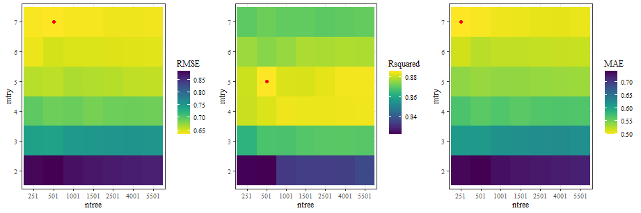

```r
p
```

Selected hyperparameters

```r
ntree <- 501
mtry <- as.integer(length(iVars)/1.25)
```

###### Run model

Train preliminary model

```r
nperm <- 5

resultsOutFluct <- crfReg(dataIn=stimDataNum, iVars=iVars, dVar=dVar, seeds=seeds[1:2], ntree=ntree, mtry=mtry, permImpCondThres=permImpCondThres, nperm=nperm, minsplit=minsplit, minbucket=minbucket)

# print model prediction results
resultsOutFluct$OOB_RMSE
```

```
[1] 0.6651969
```

```r
resultsOutFluct$OOB_MAE
```

```
[1] 0.5156219
```

```r
resultsOutFluct$Rsquared
```

```
[1] 0.8402438
```

Train multiple seeds model

```r
resultsOutFluct <- multi_crfReg(dataIn=stimDataNum, iVars=iVars, dVar=dVar, seeds=seeds, ntree=ntree, mtry=mtry, permImpCondThres=permImpCondThres, nperm=nperm, minsplit=minsplit, minbucket=minbucket)

# print model prediction results
resultsOutFluct$OOB_RMSE
```

```
[1] 0.6649845
```

```r
resultsOutFluct$OOB_MAE
```

```
[1] 0.5123997
```

```r
resultsOutFluct$Rsquared
```

```
[1] 0.8390878
```

```r
# store results
resdAnnoyMnFitAB['Abs fluct', 'RMSE'] <- resultsOutFluct$OOB_RMSE
resdAnnoyMnFitAB['Abs fluct', 'MAE'] <- resultsOutFluct$OOB_MAE
resdAnnoyMnFitAB['Abs fluct', 'Rsquared'] <- resultsOutFluct$Rsquared
resdAnnoyMnPermImpAB$AbsFluct <- resultsOutFluct$conditional_permimp
```

###### Plot results

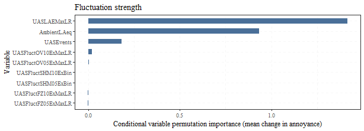

```r
par(mai=c(0,3,0,0))

# plot conditional importance
resultsOutFluct.conimp <- arrange(resultsOutFluct$conditional_permimp, desc(row_number()))

pBar <- ggplot(resultsOutFluct.conimp) + geom_col(aes(x=factor(rownames(resultsOutFluct.conimp), levels=rownames(resultsOutFluct.conimp)), y=CondPermImp), fill=mycolours[4], width=0.5) + labs(x="Variable", y="Conditional variable permutation importance (mean change in annoyance)") + ggtitle("Fluctuation strength") + theme(text = element_text(family = "serif"), panel.grid=element_line(color = rgb(235, 235, 235, 100, maxColorValue = 255), linewidth = 0.25, linetype = 2)) + coord_flip()
pBar
```

```r
if (saveplots){
  ggsave(filename="PtsABdAnnoyMnFluctConPermimp.svg", width=8, height=2.9, path=file.path(outFigPath, "svg"))
  unlink("PtsABdAnnoyMnFluctConPermimp.svg")

  ggsave(filename="PtsABdAnnoyMnFluctConPermimp.pdf", width=8, height=2.9, path=file.path(outFigPath, "pdf"))
  unlink("PtsABdAnnoyMnFluctConPermimp.pdf")
}
```

Selected metric

```r
fluctVar <- "UASFluctOV10ExMaxLR"
```

##### Roughness

###### Set variables

```r
# Roughness
iVars <- c(absVar, eventVar, ambVar, "UASRoughECMA10ExBin", "UASRoughECMA05ExBin", "UASRoughFZ10ExMaxLR", "UASRoughFZ05ExMaxLR", "UASRoughDW10ExMaxLR", "UASRoughDW05ExMaxLR")
dVar <- "dAnnoyMean"

seeds <- c(4701, 52187, 16589, 65217, 16893)
```

###### Hyperparameter tuning

```r
p <- mtryTune(dataIn=stimDataNum, iVars=iVars, dVar=dVar, seed=seeds[1:2],
             ntrees=ntrees, minsplit=minsplit, minbucket=minbucket)
```

| RMSE | Rsquared | MAE | mtry | iVars_mtry |
| --- | --- | --- | --- | --- |
| 0.9262476 | 0.7921536 | 0.7875167 | 2 | 3.50 |
| 0.8080464 | 0.8444197 | 0.6737676 | 3 | 2.75 |
| 0.7285045 | 0.8649064 | 0.5965499 | 4 | 2.25 |
| 0.6986807 | 0.8702740 | 0.5642790 | 5 | 1.75 |
| 0.6636984 | 0.8712646 | 0.5299683 | 6 | 1.50 |
| 0.6783390 | 0.8532313 | 0.5373201 | 7 | 1.25 |

| RMSE | Rsquared | MAE | mtry | iVars_mtry |
| --- | --- | --- | --- | --- |
| 0.9227701 | 0.7969551 | 0.7862340 | 2 | 3.50 |
| 0.8099358 | 0.8483816 | 0.6769953 | 3 | 2.75 |
| 0.7421832 | 0.8630545 | 0.6039333 | 4 | 2.25 |
| 0.6930117 | 0.8731645 | 0.5593280 | 5 | 1.75 |
| 0.6735562 | 0.8700246 | 0.5386980 | 6 | 1.50 |
| 0.6748987 | 0.8544430 | 0.5340114 | 7 | 1.25 |

| RMSE | Rsquared | MAE | mtry | iVars_mtry |
| --- | --- | --- | --- | --- |
| 0.9198770 | 0.7982669 | 0.7849346 | 2 | 3.50 |
| 0.8096076 | 0.8484562 | 0.6777608 | 3 | 2.75 |
| 0.7488425 | 0.8664762 | 0.6127620 | 4 | 2.25 |
| 0.6875808 | 0.8767339 | 0.5553514 | 5 | 1.75 |
| 0.6715402 | 0.8710656 | 0.5368217 | 6 | 1.50 |
| 0.6660613 | 0.8620038 | 0.5273942 | 7 | 1.25 |

| RMSE | Rsquared | MAE | mtry | iVars_mtry |
| --- | --- | --- | --- | --- |
| 0.9232289 | 0.7983996 | 0.7868398 | 2 | 3.50 |
| 0.8040576 | 0.8493111 | 0.6733709 | 3 | 2.75 |
| 0.7479029 | 0.8652079 | 0.6125473 | 4 | 2.25 |
| 0.6946116 | 0.8758077 | 0.5614886 | 5 | 1.75 |
| 0.6743674 | 0.8707719 | 0.5397152 | 6 | 1.50 |
| 0.6702984 | 0.8610669 | 0.5318910 | 7 | 1.25 |

| RMSE | Rsquared | MAE | mtry | iVars_mtry |
| --- | --- | --- | --- | --- |
| 0.9247532 | 0.7976702 | 0.7877506 | 2 | 3.50 |
| 0.8078345 | 0.8507717 | 0.6757868 | 3 | 2.75 |
| 0.7453710 | 0.8653857 | 0.6114356 | 4 | 2.25 |
| 0.6994777 | 0.8747764 | 0.5661957 | 5 | 1.75 |
| 0.6731200 | 0.8717402 | 0.5378523 | 6 | 1.50 |
| 0.6670802 | 0.8620860 | 0.5291970 | 7 | 1.25 |

| RMSE | Rsquared | MAE | mtry | iVars_mtry |
| --- | --- | --- | --- | --- |
| 0.9265731 | 0.7974343 | 0.7876956 | 2 | 3.50 |
| 0.8099869 | 0.8487677 | 0.6774686 | 3 | 2.75 |
| 0.7432385 | 0.8670445 | 0.6102531 | 4 | 2.25 |
| 0.7007180 | 0.8736936 | 0.5677264 | 5 | 1.75 |
| 0.6735329 | 0.8711748 | 0.5383303 | 6 | 1.50 |
| 0.6682665 | 0.8622546 | 0.5295891 | 7 | 1.25 |

| RMSE | Rsquared | MAE | mtry | iVars_mtry |
| --- | --- | --- | --- | --- |
| 0.9247894 | 0.7989402 | 0.7849893 | 2 | 3.50 |
| 0.8096564 | 0.8489055 | 0.6764568 | 3 | 2.75 |
| 0.7416449 | 0.8682353 | 0.6081770 | 4 | 2.25 |
| 0.7019226 | 0.8735132 | 0.5689359 | 5 | 1.75 |
| 0.6749687 | 0.8704873 | 0.5399277 | 6 | 1.50 |
| 0.6662017 | 0.8628183 | 0.5278240 | 7 | 1.25 |

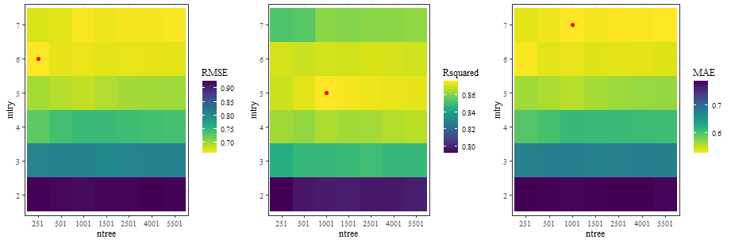

```r
p
```

Selected hyperparameters

```r
ntree <- 1001
mtry <- as.integer(length(iVars)/1.25)
```

###### Run model

Train preliminary model

```r
nperm <- 5

resultsOutRough <- crfReg(dataIn=stimDataNum, iVars=iVars, dVar=dVar, seeds=seeds[1:2], ntree=ntree, mtry=mtry, permImpCondThres=permImpCondThres, nperm=nperm, minsplit=minsplit, minbucket=minbucket)

# print model prediction results
resultsOutRough$OOB_RMSE
```

```
[1] 0.6687131
```

```r
resultsOutRough$OOB_MAE
```

```
[1] 0.5192603
```

```r
resultsOutRough$Rsquared
```

```
[1] 0.8377344
```

Train multiple seeds model

```r
resultsOutRough <- multi_crfReg(dataIn=stimDataNum, iVars=iVars, dVar=dVar, seeds=seeds, ntree=ntree, mtry=mtry, permImpCondThres=permImpCondThres, nperm=nperm, minsplit=minsplit, minbucket=minbucket)

# print model prediction results
resultsOutRough$OOB_RMSE
```

```
[1] 0.6689667
```

```r
resultsOutRough$OOB_MAE
```

```
[1] 0.5191704
```

```r
resultsOutRough$Rsquared
```

```
[1] 0.8380106
```

```r
# store results
resdAnnoyMnFitAB['Abs rough', 'RMSE'] <- resultsOutRough$OOB_RMSE
resdAnnoyMnFitAB['Abs rough', 'MAE'] <- resultsOutRough$OOB_MAE
resdAnnoyMnFitAB['Abs rough', 'Rsquared'] <- resultsOutRough$Rsquared
resdAnnoyMnPermImpAB$AbsRough <- resultsOutRough$conditional_permimp
```

###### Plot results

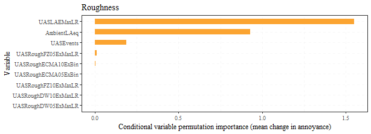

```r
par(mai=c(0,3,0,0))

# plot conditional importance
resultsOutRough.conimp <- arrange(resultsOutRough$conditional_permimp, desc(row_number()))

pBar <- ggplot(resultsOutRough.conimp) + geom_col(aes(x=factor(rownames(resultsOutRough.conimp), levels=rownames(resultsOutRough.conimp)), y=CondPermImp), fill=mycolours[5], width=0.5) + labs(x="Variable", y="Conditional variable permutation importance (mean change in annoyance)") + ggtitle("Roughness") + theme(text = element_text(family = "serif"), panel.grid=element_line(color = rgb(235, 235, 235, 100, maxColorValue = 255), linewidth = 0.25, linetype = 2)) + coord_flip()
pBar
```

```r
if (saveplots){
  ggsave(filename="PtsABdAnnoyMnRoughConPermimp.svg", width=8, height=2.9, path=file.path(outFigPath, "svg"))
  unlink("PtsABdAnnoyMnRoughConPermimp.svg")

  ggsave(filename="PtsABdAnnoyMnRoughConPermimp.pdf", width=8, height=2.9, path=file.path(outFigPath, "pdf"))
  unlink("PtsABdAnnoyMnRoughConPermimp.pdf")
}
```

Selected metric

```r
roughVar <- "UASRoughFZ05ExMaxLR"
```

##### Impulsiveness

###### Set variables

```r
# Impulsiveness
iVars <- c(absVar, eventVar, ambVar, "UASImpulsSHMAvgMaxLR", "UASImpulsSHM05ExMaxLR", "UASImpulsSHMPowAvgMaxLR")
dVar <- "dAnnoyMean"

seeds <- c(8495, 59867, 5416, 9843, 86)
```

###### Hyperparameter tuning

```r
p <- mtryTune(dataIn=stimDataNum, iVars=iVars, dVar=dVar, seed=seeds[1:2],
             ntrees=ntrees, minsplit=minsplit, minbucket=minbucket)
```

| RMSE | Rsquared | MAE | mtry | iVars_mtry |
| --- | --- | --- | --- | --- |
| 0.7300998 | 0.8825931 | 0.5961358 | 3 | 1.75 |

| RMSE | Rsquared | MAE | mtry | iVars_mtry |
| --- | --- | --- | --- | --- |
| 0.7389876 | 0.8783975 | 0.6037359 | 3 | 1.75 |

| RMSE | Rsquared | MAE | mtry | iVars_mtry |
| --- | --- | --- | --- | --- |
| 0.7341945 | 0.880855 | 0.6037753 | 3 | 1.75 |

| RMSE | Rsquared | MAE | mtry | iVars_mtry |
| --- | --- | --- | --- | --- |
| 0.7352012 | 0.8820747 | 0.6017992 | 3 | 1.75 |

| RMSE | Rsquared | MAE | mtry | iVars_mtry |
| --- | --- | --- | --- | --- |
| 0.7333753 | 0.8829768 | 0.6008367 | 3 | 1.75 |

| RMSE | Rsquared | MAE | mtry | iVars_mtry |
| --- | --- | --- | --- | --- |
| 0.7332335 | 0.8829437 | 0.6007477 | 3 | 1.75 |

| RMSE | Rsquared | MAE | mtry | iVars_mtry |
| --- | --- | --- | --- | --- |
| 0.7343272 | 0.8833404 | 0.6015248 | 3 | 1.75 |

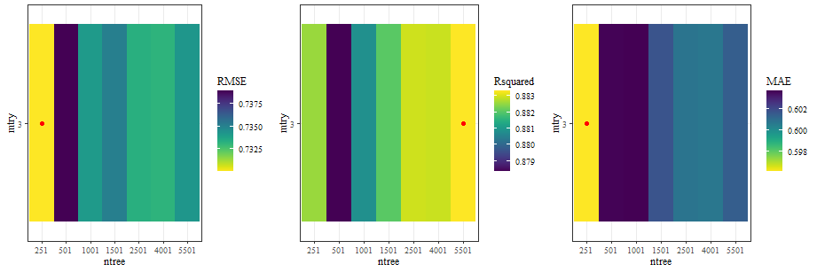

```r
p
```

Selected hyperparameters

```r
ntree <- 251
mtry <- as.integer(length(iVars)/1.75)
```

###### Run model

Train preliminary model

```r
nperm <- 5

resultsOutImpuls <- crfReg(dataIn=stimDataNum, iVars=iVars, dVar=dVar, seeds=seeds[1:2], ntree=ntree, mtry=mtry, permImpCondThres=permImpCondThres, nperm=nperm, minsplit=minsplit, minbucket=minbucket)

# print model prediction results
resultsOutImpuls$OOB_RMSE
```

```
[1] 0.6523864
```

```r
resultsOutImpuls$OOB_MAE
```

```
[1] 0.5137712
```

```r
resultsOutImpuls$Rsquared
```

```
[1] 0.8767983
```

Train multiple seeds model

```r
resultsOutImpuls <- multi_crfReg(dataIn=stimDataNum, iVars=iVars, dVar=dVar, seeds=seeds, ntree=ntree, mtry=mtry, permImpCondThres=permImpCondThres, nperm=nperm, minsplit=minsplit, minbucket=minbucket)

# print model prediction results
resultsOutImpuls$OOB_RMSE
```

```
[1] 0.6582522
```

```r
resultsOutImpuls$OOB_MAE
```

```
[1] 0.5243145
```

```r
resultsOutImpuls$Rsquared
```

```
[1] 0.8755664
```

```r
# store results
resdAnnoyMnFitAB['Abs impuls', 'RMSE'] <- resultsOutImpuls$OOB_RMSE
resdAnnoyMnFitAB['Abs impuls', 'MAE'] <- resultsOutImpuls$OOB_MAE
resdAnnoyMnFitAB['Abs impuls', 'Rsquared'] <- resultsOutImpuls$Rsquared
resdAnnoyMnPermImpAB$AbsImpuls <- resultsOutImpuls$conditional_permimp
```

###### Plot results

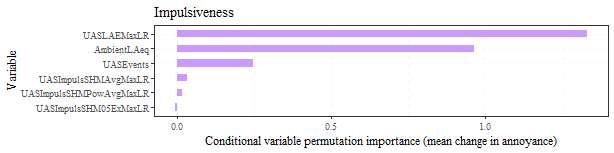

```r
par(mai=c(0,3,0,0))

# plot conditional importance
resultsOutImpuls.conimp <- arrange(resultsOutImpuls$conditional_permimp, desc(row_number()))

pBar <- ggplot(resultsOutImpuls.conimp) + geom_col(aes(x=factor(rownames(resultsOutImpuls.conimp), levels=rownames(resultsOutImpuls.conimp)), y=CondPermImp), fill=mycolours[6], width=0.5) + labs(x="Variable", y="Conditional variable permutation importance (mean change in annoyance)") + ggtitle("Impulsiveness") + theme(text = element_text(family = "serif"), panel.grid=element_line(color = rgb(235, 235, 235, 100, maxColorValue = 255), linewidth = 0.25, linetype = 2)) + coord_flip()
pBar
```

```r
if (saveplots){
  ggsave(filename="PtsABdAnnoyMnImpulsConPermimp.svg", width=8, height=2, path=file.path(outFigPath, "svg"))
  unlink("PtsABdAnnoyMnImpulsConPermimp.svg")

  ggsave(filename="PtsABdAnnoyMnImpulsConPermimp.pdf", width=8, height=2, path=file.path(outFigPath, "pdf"))
  unlink("PtsABdAnnoyMnImpulsConPermimp.pdf")
}
```

Selected metric

```r
impulsVar <- "UASImpulsSHMAvgMaxLR"
```

#### SQM and loudness comparison

Now the highest importance SQMs are ranked against each other, controlling for UAS loudness and ambient LAeq.

##### Include tonal loudness

###### Set variables

```r
iVars <- c(absVar, eventVar, ambVar, sharpVar, tonLdVar, fluctVar, roughVar, impulsVar)
dVar <- "dAnnoyMean"

seeds <- c(70498, 4, 14986, 453, 864)
```

###### Hyperparameter tuning

```r
p <- mtryTune(dataIn=stimDataNum, iVars=iVars, dVar=dVar, seed=seeds[1:2],
             ntrees=ntrees, minsplit=minsplit, minbucket=minbucket)
```

| RMSE | Rsquared | MAE | mtry | iVars_mtry |
| --- | --- | --- | --- | --- |
| 0.7320555 | 0.8510588 | 0.6102445 | 3 | 2.25 |
| 0.6631054 | 0.8734466 | 0.5469535 | 4 | 1.75 |
| 0.6653247 | 0.8618001 | 0.5483481 | 5 | 1.50 |
| 0.6472966 | 0.8635581 | 0.5303188 | 6 | 1.25 |

| RMSE | Rsquared | MAE | mtry | iVars_mtry |
| --- | --- | --- | --- | --- |
| 0.7262390 | 0.8587760 | 0.6042522 | 3 | 2.25 |
| 0.6673484 | 0.8716507 | 0.5520283 | 4 | 1.75 |
| 0.6522762 | 0.8710962 | 0.5386112 | 5 | 1.50 |
| 0.6416754 | 0.8672152 | 0.5253931 | 6 | 1.25 |

| RMSE | Rsquared | MAE | mtry | iVars_mtry |
| --- | --- | --- | --- | --- |
| 0.7243089 | 0.8602585 | 0.6032546 | 3 | 2.25 |
| 0.6643029 | 0.8742387 | 0.5491499 | 4 | 1.75 |
| 0.6498944 | 0.8723225 | 0.5359868 | 5 | 1.50 |
| 0.6422571 | 0.8672327 | 0.5245522 | 6 | 1.25 |

| RMSE | Rsquared | MAE | mtry | iVars_mtry |
| --- | --- | --- | --- | --- |
| 0.7282246 | 0.8580420 | 0.6083830 | 3 | 2.25 |
| 0.6662854 | 0.8747989 | 0.5520703 | 4 | 1.75 |
| 0.6497621 | 0.8723811 | 0.5354915 | 5 | 1.50 |
| 0.6409707 | 0.8686945 | 0.5228809 | 6 | 1.25 |

| RMSE | Rsquared | MAE | mtry | iVars_mtry |
| --- | --- | --- | --- | --- |
| 0.7238831 | 0.8615554 | 0.6059076 | 3 | 2.25 |
| 0.6667753 | 0.8757358 | 0.5529677 | 4 | 1.75 |
| 0.6510004 | 0.8718800 | 0.5365955 | 5 | 1.50 |
| 0.6408936 | 0.8689582 | 0.5225740 | 6 | 1.25 |

| RMSE | Rsquared | MAE | mtry | iVars_mtry |
| --- | --- | --- | --- | --- |
| 0.7215289 | 0.8630445 | 0.6042821 | 3 | 2.25 |
| 0.6663160 | 0.8754418 | 0.5529980 | 4 | 1.75 |
| 0.6517680 | 0.8717751 | 0.5365914 | 5 | 1.50 |
| 0.6387300 | 0.8701406 | 0.5208794 | 6 | 1.25 |

| RMSE | Rsquared | MAE | mtry | iVars_mtry |
| --- | --- | --- | --- | --- |
| 0.7201819 | 0.8634895 | 0.6025876 | 3 | 2.25 |
| 0.6690367 | 0.8749197 | 0.5561127 | 4 | 1.75 |
| 0.6509062 | 0.8720829 | 0.5354466 | 5 | 1.50 |
| 0.6389263 | 0.8701478 | 0.5212022 | 6 | 1.25 |

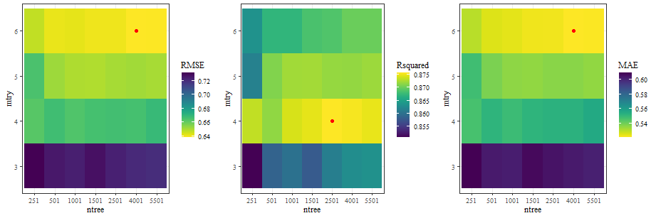

```r
p
```

Selected hyperparameters

```r
ntree <- 4001
mtry <- as.integer(length(iVars)/1.25)
```

###### Run model

Train preliminary model

```r
nperm <- 5

resultsOutSQMs1 <- crfReg(dataIn=stimDataNum, iVars=iVars, dVar=dVar, seeds=seeds[1:2], ntree=ntree, mtry=mtry, permImpCondThres=permImpCondThres, nperm=nperm, minsplit=minsplit, minbucket=minbucket)

# print model prediction results
resultsOutSQMs1$OOB_RMSE
```

```
[1] 0.6651241
```

```r
resultsOutSQMs1$OOB_MAE
```

```
[1] 0.5213305
```

```r
resultsOutSQMs1$Rsquared
```

```
[1] 0.8419727
```

Train multiple seeds model

```r
resultsOutSQMs1 <- multi_crfReg(dataIn=stimDataNum, iVars=iVars, dVar=dVar, seeds=seeds, ntree=ntree, mtry=mtry, permImpCondThres=permImpCondThres, nperm=nperm, minsplit=minsplit, minbucket=minbucket)

# print model prediction results
resultsOutSQMs1$OOB_RMSE
```

```
[1] 0.6677585
```

```r
resultsOutSQMs1$OOB_MAE
```

```
[1] 0.5213994
```

```r
resultsOutSQMs1$Rsquared
```

```
[1] 0.8399029
```

```r
# store results
resdAnnoyMnFitAB['Abs SQMs inc tonal loud', 'RMSE'] <- resultsOutSQMs1$OOB_RMSE
resdAnnoyMnFitAB['Abs SQMs inc tonal loud', 'MAE'] <- resultsOutSQMs1$OOB_MAE
resdAnnoyMnFitAB['Abs SQMs inc tonal loud', 'Rsquared'] <- resultsOutSQMs1$Rsquared
resdAnnoyMnPermImpAB$AbsSQMs1 <- resultsOutSQMs1$conditional_permimp
```

###### Plot results

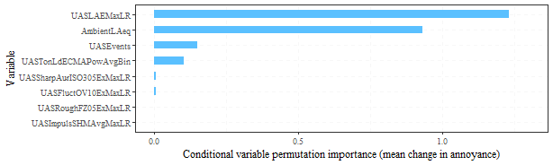

```r
par(mai=c(0,3,0,0))

# plot conditional importance
resultsOutSQMs1.conimp <- arrange(resultsOutSQMs1$conditional_permimp, desc(row_number()))

pBar <- ggplot(resultsOutSQMs1.conimp) + geom_col(aes(x=factor(rownames(resultsOutSQMs1.conimp), levels=rownames(resultsOutSQMs1.conimp)), y=CondPermImp), fill=mycolours[7], width=0.5) + labs(x="Variable", y="Conditional variable permutation importance (mean change in annoyance)") + theme(text = element_text(family = "serif"), panel.grid=element_line(color = rgb(235, 235, 235, 100, maxColorValue = 255), linewidth = 0.25, linetype = 2)) + coord_flip(ylim=c(0, 1.3))
pBar
```

```r
if (saveplots){
  ggsave(filename="PtsABdAnnoyMnAbsSQMsTonLdConPermimp.svg", width=8, height=2.4, path=file.path(outFigPath, "svg"))
  unlink("PtsABdAnnoyMnAbsSQMsTonLdConPermimp.svg")

  ggsave(filename="PtsABdAnnoyMnAbsSQMsTonLdConPermimp.pdf", width=8, height=2.4, path=file.path(outFigPath, "pdf"))
  unlink("PtsABdAnnoyMnAbsSQMsTonLdConPermimp.pdf")
}
```

##### Exclude tonal loudness

###### Set variables

```r
iVars <- c(absVar, eventVar, ambVar, sharpVar, tonalVar, fluctVar, roughVar, impulsVar)
dVar <- "dAnnoyMean"

seeds <- c(546, 57203, 270835, 60592, 8094)
```

###### Hyperparameter tuning

```r
p <- mtryTune(dataIn=stimDataNum, iVars=iVars, dVar=dVar, seed=seeds[1:2],
             ntrees=ntrees, minsplit=minsplit, minbucket=minbucket)
```

| RMSE | Rsquared | MAE | mtry | iVars_mtry |
| --- | --- | --- | --- | --- |
| 0.7056934 | 0.8695159 | 0.5915235 | 3 | 2.25 |
| 0.6722795 | 0.8788044 | 0.5486298 | 4 | 1.75 |
| 0.6357060 | 0.8785342 | 0.5252640 | 5 | 1.50 |
| 0.6544287 | 0.8624925 | 0.5236170 | 6 | 1.25 |

| RMSE | Rsquared | MAE | mtry | iVars_mtry |
| --- | --- | --- | --- | --- |
| 0.7194542 | 0.8644882 | 0.6006949 | 3 | 2.25 |
| 0.6792619 | 0.8754575 | 0.5579033 | 4 | 1.75 |
| 0.6388163 | 0.8823786 | 0.5251731 | 5 | 1.50 |
| 0.6560924 | 0.8609518 | 0.5255014 | 6 | 1.25 |

| RMSE | Rsquared | MAE | mtry | iVars_mtry |
| --- | --- | --- | --- | --- |
| 0.7176447 | 0.8652670 | 0.5962337 | 3 | 2.25 |
| 0.6764974 | 0.8766555 | 0.5587249 | 4 | 1.75 |
| 0.6396189 | 0.8810041 | 0.5254416 | 5 | 1.50 |
| 0.6493761 | 0.8637378 | 0.5242789 | 6 | 1.25 |

| RMSE | Rsquared | MAE | mtry | iVars_mtry |
| --- | --- | --- | --- | --- |
| 0.7215618 | 0.8647706 | 0.5984599 | 3 | 2.25 |
| 0.6729972 | 0.8781050 | 0.5566702 | 4 | 1.75 |
| 0.6429652 | 0.8802155 | 0.5290328 | 5 | 1.50 |
| 0.6451662 | 0.8672044 | 0.5205613 | 6 | 1.25 |

| RMSE | Rsquared | MAE | mtry | iVars_mtry |
| --- | --- | --- | --- | --- |
| 0.7204231 | 0.8654246 | 0.5972381 | 3 | 2.25 |
| 0.6740811 | 0.8773531 | 0.5572070 | 4 | 1.75 |
| 0.6499355 | 0.8765187 | 0.5335599 | 5 | 1.50 |
| 0.6418077 | 0.8684562 | 0.5160019 | 6 | 1.25 |

| RMSE | Rsquared | MAE | mtry | iVars_mtry |
| --- | --- | --- | --- | --- |
| 0.7258869 | 0.8629824 | 0.6017781 | 3 | 2.25 |
| 0.6729134 | 0.8767254 | 0.5567036 | 4 | 1.75 |
| 0.6522204 | 0.8744611 | 0.5344397 | 5 | 1.50 |
| 0.6403828 | 0.8696989 | 0.5150474 | 6 | 1.25 |

| RMSE | Rsquared | MAE | mtry | iVars_mtry |
| --- | --- | --- | --- | --- |
| 0.7248200 | 0.8638228 | 0.6010765 | 3 | 2.25 |
| 0.6715068 | 0.8770042 | 0.5557459 | 4 | 1.75 |
| 0.6516472 | 0.8751895 | 0.5341838 | 5 | 1.50 |
| 0.6399006 | 0.8699269 | 0.5146922 | 6 | 1.25 |

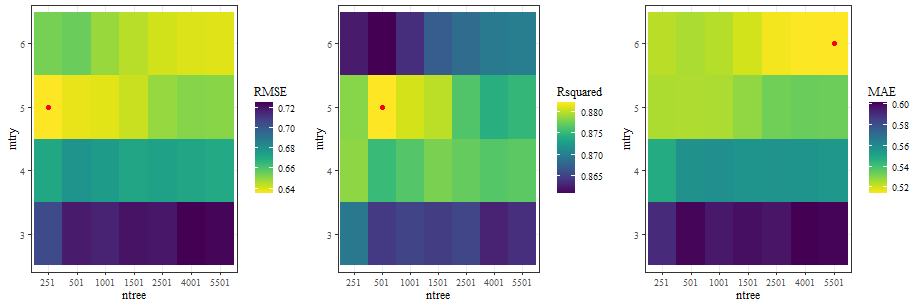

```r
p
```

Selected hyperparameters

```r
ntree <- 501
mtry <- as.integer(length(iVars)/1.5)
```

###### Run model

Train preliminary model

```r
nperm <- 5

resultsOutSQMs2 <- crfReg(dataIn=stimDataNum, iVars=iVars, dVar=dVar, seeds=seeds[1:2], ntree=ntree, mtry=mtry, permImpCondThres=permImpCondThres, nperm=nperm, minsplit=minsplit, minbucket=minbucket)

# print model prediction results
resultsOutSQMs2$OOB_RMSE
```

```
[1] 0.6556551
```

```r
resultsOutSQMs2$OOB_MAE
```

```
[1] 0.518481
```

```r
resultsOutSQMs2$Rsquared
```

```
[1] 0.8510753
```

Train multiple seeds model

```r
resultsOutSQMs2 <- multi_crfReg(dataIn=stimDataNum, iVars=iVars, dVar=dVar, seeds=seeds, ntree=ntree, mtry=mtry, permImpCondThres=permImpCondThres, nperm=nperm, minsplit=minsplit, minbucket=minbucket)

# print model prediction results
resultsOutSQMs2$OOB_RMSE
```

```
[1] 0.6576765
```

```r
resultsOutSQMs2$OOB_MAE
```

```
[1] 0.5154716
```

```r
resultsOutSQMs2$Rsquared
```

```
[1] 0.8499749
```

```r
# store results
resdAnnoyMnFitAB['Abs SQMs no tonal loud', 'RMSE'] <- resultsOutSQMs2$OOB_RMSE
resdAnnoyMnFitAB['Abs SQMs no tonal loud', 'RMSE'] <- resultsOutSQMs2$OOB_MAE
resdAnnoyMnFitAB['Abs SQMs no tonal loud', 'Rsquared'] <- resultsOutSQMs2$Rsquared
resdAnnoyMnPermImpAB$AbsSQMs2 <- resultsOutSQMs2$conditional_permimp
```

###### Plot results

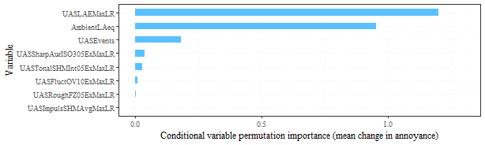

```r
par(mai=c(0,3,0,0))

# plot conditional importance
resultsOutSQMs2.conimp <- arrange(resultsOutSQMs2$conditional_permimp, desc(row_number()))

pBar <- ggplot(resultsOutSQMs2.conimp) + geom_col(aes(x=factor(rownames(resultsOutSQMs2.conimp), levels=rownames(resultsOutSQMs2.conimp)), y=CondPermImp), fill=mycolours[7], width=0.5) + labs(x="Variable", y="Conditional variable permutation importance (mean change in annoyance)") + theme(text = element_text(family = "serif"), panel.grid=element_line(color = rgb(235, 235, 235, 100, maxColorValue = 255), linewidth = 0.25, linetype = 2)) + coord_flip(ylim=c(0, 1.3))
pBar
```

```r
if (saveplots){
  ggsave(filename="PtsABdAnnoyMnAbsSQMsNoTonLdConPermimp.svg", width=8, height=2.4, path=file.path(outFigPath, "svg"))
  unlink("PtsABdAnnoyMnAbsSQMsNoTonLdConPermimp.svg")

  ggsave(filename="PtsABdAnnoyMnAbsSQMsNoTonLdConPermimp.pdf", width=8, height=2.4, path=file.path(outFigPath, "pdf"))
  unlink("PtsABdAnnoyMnAbsSQMsNoTonLdConPermimp.pdf")
}
```